# Practica Fundamentos

## DETECCIÓN E IMPUTACIÓN DE DATOS FALTANTES

Se realiza un análisis de la existencia de datos faltantes.

### Datos faltantes

Se genera un 5% de datos faltantes en las variables **“grade”, “sqft_living15” y “sqft_basement”**.

```r
miss <- c("grade", "sqft_living15","sqft_basement")
train_na <- train %>% select(miss)
```

```
## Note: Using an external vector in selections is ambiguous.
## i Use `all_of(miss)` instead of `miss` to silence this message.
## i See <https://tidyselect.r-lib.org/reference/faq-external-vector.html>.
```

```r
train_miss <- prodNA(train_na, 0.05)

var <- c("lat", "long", "id", "date", "price","bedrooms","bathrooms","sqft_living","sqft_lot", "floors","view","waterfront", "condition","sqft_above","sqft_lot15","yr_built","yr_renovated","zipcode","sale_date","sale_year","sale_month","sale_quarter","sale_tenure","yr_since_last_renovated","price_m2","Dist_from_seattle")

train_new <- train %>% select(var)
```

```
## Note: Using an external vector in selections is ambiguous.
## i Use `all_of(var)` instead of `var` to silence this message.
## i See <https://tidyselect.r-lib.org/reference/faq-external-vector.html>.
```

```r
train_miss_new <- cbind(train_miss,train_new)
colSums(is.na(train_miss_new))
```

```
##                   grade           sqft_living15           sqft_basement
##                     772                     795                     829
##                     lat                    long                      id
##                       0                       0                       0
##                    date                   price                bedrooms
##                       0                       0                       0
##               bathrooms             sqft_living                sqft_lot
##                       0                       0                       0
##                  floors                    view              waterfront
##                       0                       0                       0
##               condition              sqft_above              sqft_lot15
##                       0                       1                       0
##                yr_built            yr_renovated                 zipcode
##                       0                       0                       0
##               sale_date               sale_year              sale_month
##                       0                       0                       0
##            sale_quarter             sale_tenure yr_since_last_renovated
##                       0                       0                       0
##                price_m2       Dist_from_seattle
##                       0                       0
```

Datos de las variables con valor = **0**

```r
colSums(train==0)
```

```
##                     lat                    long                      id
##                       0                       0                       0
##                    date                   price                bedrooms
##                       0                       0                       9
##               bathrooms             sqft_living                sqft_lot
##                       7                       0                       0
##                  floors              waterfront                    view
##                       0                   15868                   14454
##               condition                   grade              sqft_above
##                       0                       0                      NA
##           sqft_basement                yr_built            yr_renovated
##                    9816                       0                   15330
##                 zipcode           sqft_living15              sqft_lot15
##                       0                       0                       0
##               sale_date               sale_year              sale_month
##                       0                       0                       0
##            sale_quarter             sale_tenure yr_since_last_renovated
##                       0                     365                   15394
##                price_m2       Dist_from_seattle                Clusters
##                       0                       0                       0
```

Análisis del patron de datos faltantes.

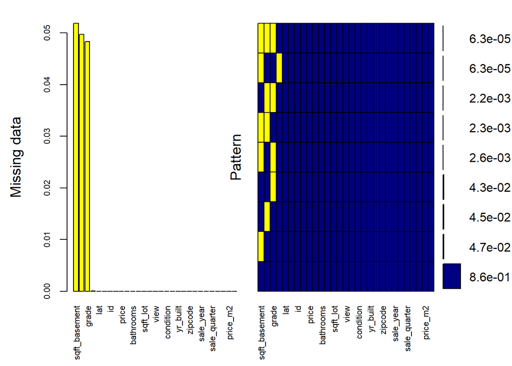

```
##
##  Variables sorted by number of missings:
##                 Variable        Count
##            sqft_basement 5.188059e-02
##            sqft_living15 4.975280e-02
##                    grade 4.831341e-02
##               sqft_above 6.258214e-05
##                      lat 0.000000e+00
##                     long 0.000000e+00
##                       id 0.000000e+00
##                     date 0.000000e+00
##                    price 0.000000e+00
##                 bedrooms 0.000000e+00
##                bathrooms 0.000000e+00
##              sqft_living 0.000000e+00
##                 sqft_lot 0.000000e+00
##                   floors 0.000000e+00
##                     view 0.000000e+00
##               waterfront 0.000000e+00
##                condition 0.000000e+00
##               sqft_lot15 0.000000e+00
##                 yr_built 0.000000e+00
##             yr_renovated 0.000000e+00
##                  zipcode 0.000000e+00
##                sale_date 0.000000e+00
##                sale_year 0.000000e+00
##               sale_month 0.000000e+00
##             sale_quarter 0.000000e+00
##              sale_tenure 0.000000e+00
##  yr_since_last_renovated 0.000000e+00
##                 price_m2 0.000000e+00
##        Dist_from_seattle 0.000000e+00
```

```r
mice_plot <- aggr(train_miss_new, col=c('navyblue','yellow'),
                    numbers=TRUE, sortVars=TRUE,
                    labels=names(train_miss_new), cex.axis=.7,
                    gap=1, ylab=c("Missing data","Pattern"))
```

### Imputación de datos faltantes

```r
imputed <- train_miss_new %>% select(grade, bathrooms, bedrooms,price) %>% VIM::kNN(variable='grade')
imputed <- train_miss_new %>% select(sqft_basement, sqft_living, sqft_above,bedrooms, bathrooms,price) %>% VIM::kNN(variable='sqft_basement')
imputed <- train_miss_new %>% select(sqft_living15, sqft_living, sqft_above, bathrooms, bedrooms, price) %>% VIM::kNN(variable='sqft_living15')


train_miss_new$grade <- imputed$grade
train_miss_new$sqft_basement <- imputed$sqft_basement
train_miss_new$sqft_living15 <- imputed$sqft_living15
head(train_miss_new)
```

```
##   sqft_living15     lat     long         id            date  price bedrooms
## 1          2280 47.1593 -121.957  619079016 20140602T000000 687000        4
## 2          1280 47.1622 -121.971  619079096 20150406T000000 750000        3
## 3          1560 47.1647 -121.973  619079061 20140619T000000 335000        4
## 4          1880 47.1775 -122.022 3420069065 20140825T000000 360000        4
## 5          2240 47.1776 -121.944 3220079017 20150213T000000 432000        5
## 6          1530 47.1776 -122.011 3520069033 20140623T000000 230000        3
##   bathrooms sqft_living sqft_lot floors view waterfront condition sqft_above
## 1      3.25        4400   186846    2.0    0          0         4       4400
## 2      2.50        2350   715690    1.5    0          0         4       2350
## 3      2.00        2030   103672    1.0    0          0         4       2030
## 4      1.75        3730    16980    1.0    0          0         4       2150
## 5      2.75        2060   329903    1.5    3          0         5       2060
## 6      1.00        1530   389126    1.5    0          0         4       1530
##   sqft_lot15 yr_built yr_renovated zipcode  sale_date sale_year sale_month
## 1     186846     1993            0   98022 2014-06-02      2014         06
## 2     325393     1979            0   98022 2015-04-06      2015         04
## 3     325393     1969            0   98022 2014-06-19      2014         06
## 4      16963     1974            0   98022 2014-08-25      2014         08
## 5     220232     1989            0   98022 2015-02-13      2015         02
## 6      42148     1919            0   98022 2014-06-23      2014         06
##   sale_quarter sale_tenure yr_since_last_renovated  price_m2 Dist_from_seattle
## 1           Q2          21                       0 156.13636          57510.72
## 2           Q2          36                       0 319.14894          56712.04
## 3           Q2          45                       0 165.02463          56395.24
## 4           Q3          40                       0  96.51475          53420.17
## 5           Q1          26                       0 209.70874          56255.11
## 6           Q2          95                       0 150.32680          53781.59
```

Nº filas coinciden sqft_living y sqft_above

```r
sqft_compare <- train[, c("sqft_living", "sqft_above")]
nrow(subset(sqft_compare, sqft_living == sqft_above))
```

```
## [1] 9815
```

## TRANSFORMACIÓN DE VARIABLES

```r
#Creamos dataframe que incluya las variables sin modificar y transformadas

trans_var <- train
```

### Transformaciones

Transformacion de **price** con **log10**

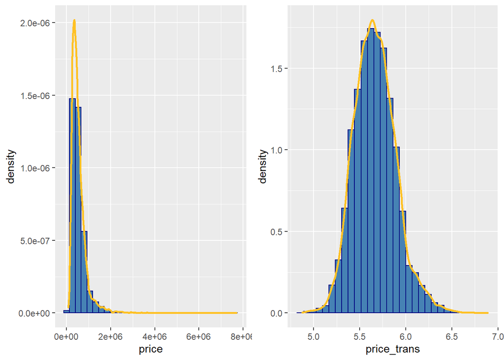

```r
#Transformacion price con log10

price_trans <- log10(trans_var$price)
trans_var <- mutate(train, price_trans)

p1 <- ggplot(trans_var, aes(x=price)) + geom_histogram(aes(y=..density..), colour = "navy", fill = "steelblue", bins=30) + geom_density(colour = "goldenrod1", size = 1)
p2 <- ggplot(trans_var, aes(x=price_trans)) + geom_histogram(aes(y=..density..), colour = "navy", fill = "steelblue", bins=30) + geom_density(colour = "goldenrod1", size = 1)
grid.arrange(p1, p2, nrow=1)
```

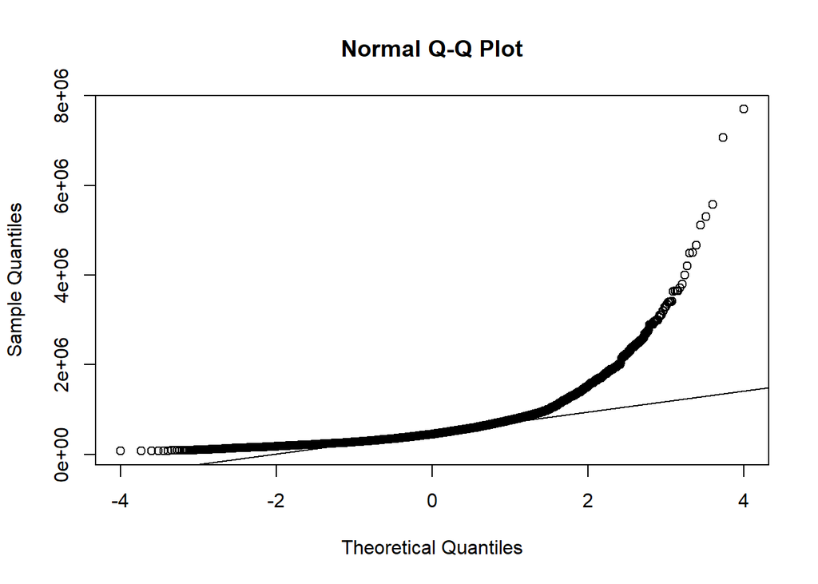

```r
qqnorm(trans_var$price)
qqline(trans_var$price)
```

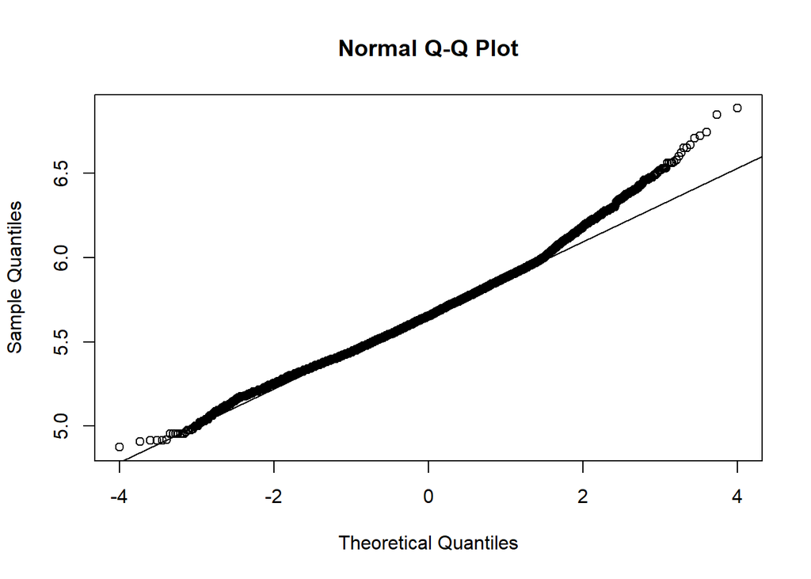

```r
qqnorm(trans_var$price_trans)
qqline(trans_var$price_trans)
```

Transformacion de **bedrooms** a **dummie**, factor, y quitamos el 33

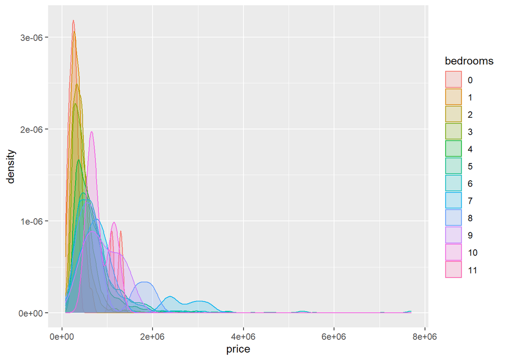

```r
#Transformacion bedrooms a dummie, factor, y quitamos el 33

trans_var$bedrooms= as.factor(trans_var$bedrooms)
df_bedrooms <- trans_var[, c("price", "bedrooms")]
df_bedrooms <- subset(df_bedrooms, bedrooms != 33)
ggplot(df_bedrooms, aes(x=price, color=bedrooms, fill=bedrooms)) + geom_density(alpha=.2)
```

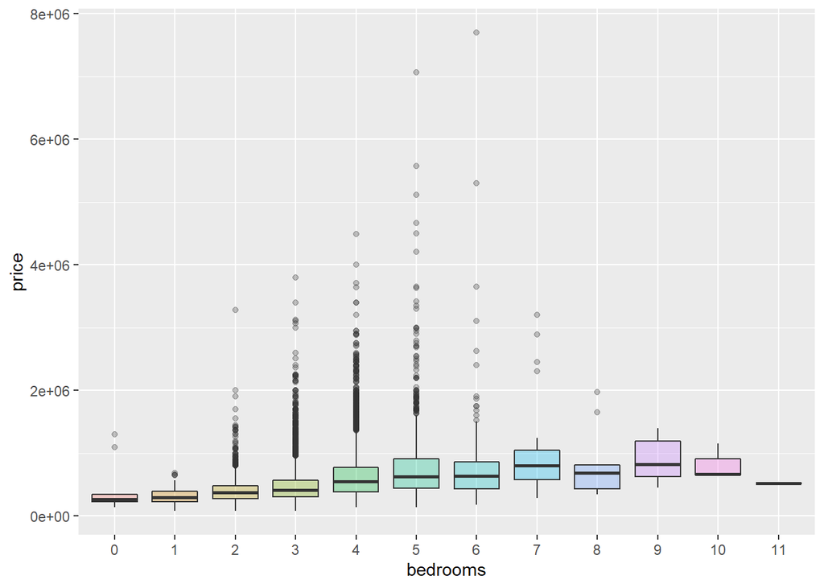

```r
ggplot(df_bedrooms, aes(x=bedrooms, y=price, fill=bedrooms)) +  geom_boxplot(alpha=0.3) + theme(legend.position="none")
```

Transformacion de **bathrooms** a **dummie**, factor, y redondeamos hacia arriba

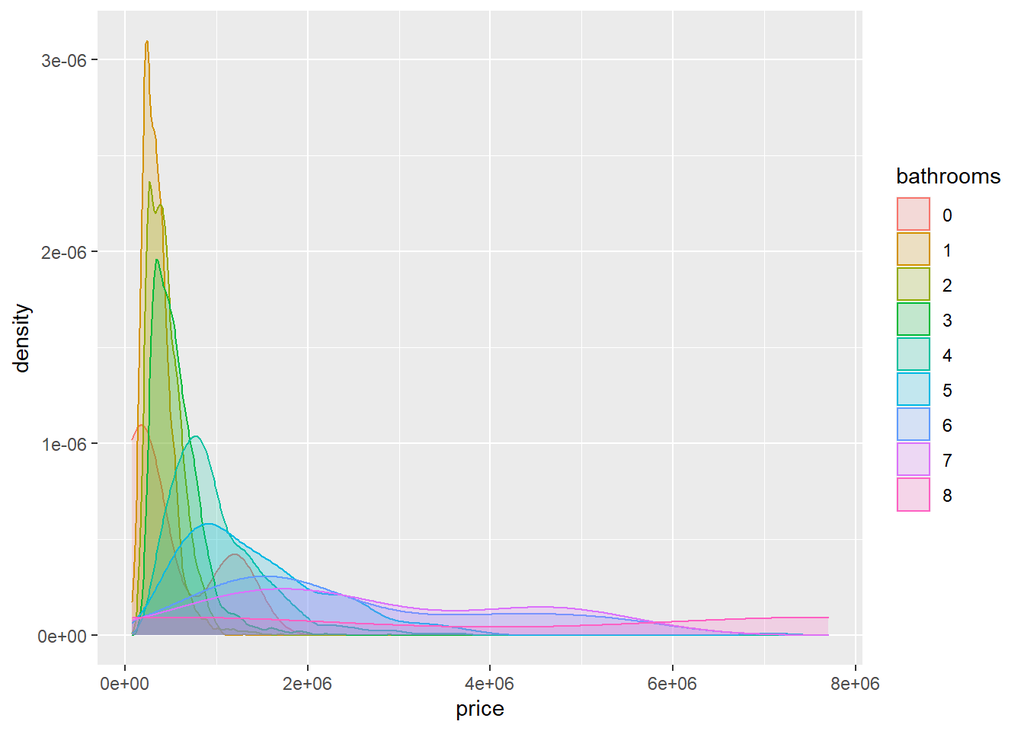

```r
#Transformacion bathrooms, redondeamos arriba y transformamos a factor

df_bathrooms <- trans_var[, c("price", "bathrooms")]
df_bathrooms$bathrooms <- ceiling(df_bathrooms$bathrooms)
trans_var$bathrooms= as.factor(df_bathrooms$bathrooms)
df_bathrooms$bathrooms= as.factor(df_bathrooms$bathrooms)
ggplot(df_bathrooms, aes(x=price, color=bathrooms, fill=bathrooms)) + geom_density(alpha=.2)
```

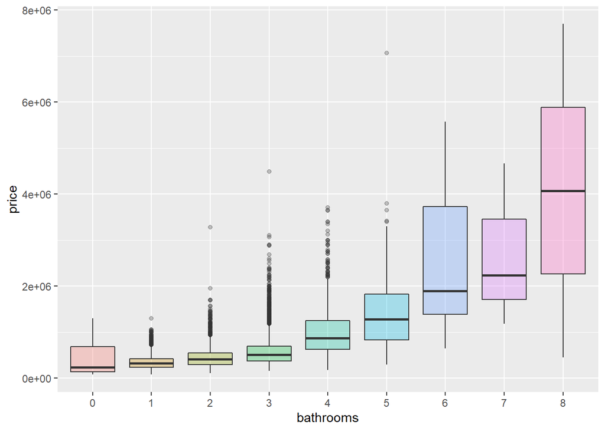

```r
ggplot(df_bathrooms, aes(x=bathrooms, y=price, fill=bathrooms)) +  geom_boxplot(alpha=0.3) + theme(legend.position="none")
```

Transformacion de **sqft_living** con **log10**

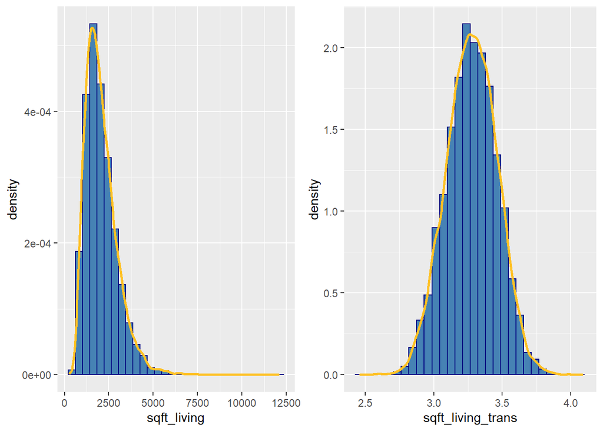

```r
#Transformacion sqft_living con log10

sqft_living_trans <- log10(trans_var$sqft_living)
trans_var <- mutate(train, sqft_living_trans)

p1 <- ggplot(trans_var, aes(x=sqft_living)) + geom_histogram(aes(y=..density..), colour = "navy", fill = "steelblue", bins=30) + geom_density(colour = "goldenrod1", size = 1)
p2 <- ggplot(trans_var, aes(x=sqft_living_trans)) + geom_histogram(aes(y=..density..), colour = "navy", fill = "steelblue", bins=30) + geom_density(colour = "goldenrod1", size = 1)
grid.arrange(p1, p2, nrow=1)
```

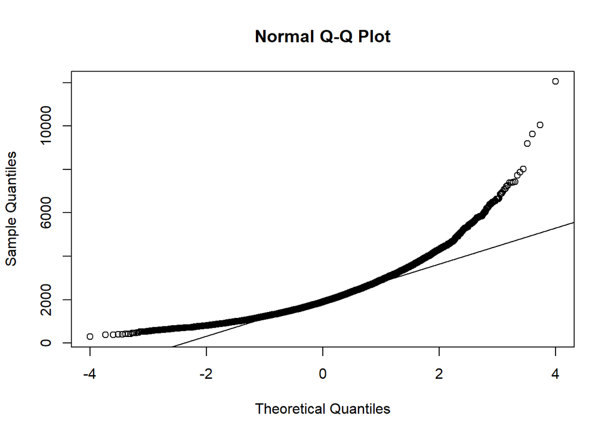

```r
qqnorm(trans_var$sqft_living)
qqline(trans_var$sqft_living)
```

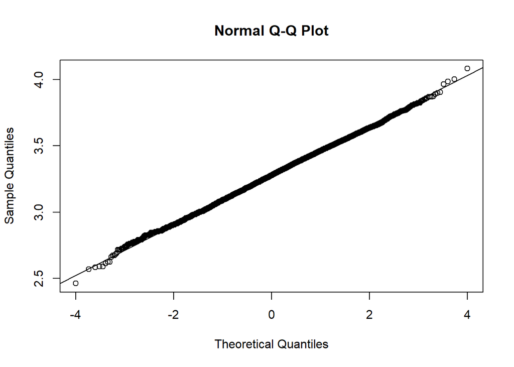

```r
qqnorm(trans_var$sqft_living_trans)
qqline(trans_var$sqft_living_trans)
```

Transformacion de **sqft_lot** con **log10**

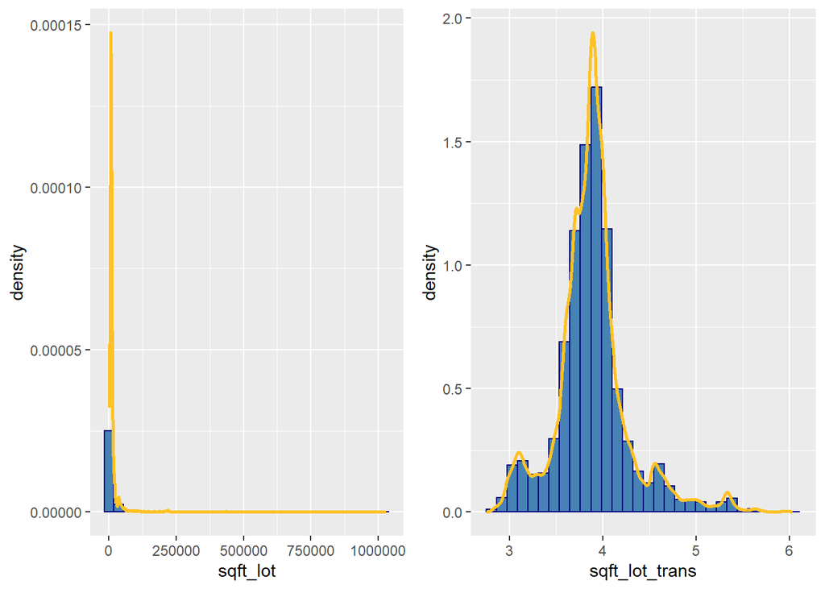

```r
#Transformacion sqft_lot con log10

sqft_lot_trans <- log10(trans_var$sqft_lot)
trans_var <- mutate(train, sqft_lot_trans)

p1 <- ggplot(trans_var, aes(x=sqft_lot)) + geom_histogram(aes(y=..density..), colour = "navy", fill = "steelblue", bins=30) + geom_density(colour = "goldenrod1", size = 1)
p2 <- ggplot(trans_var, aes(x=sqft_lot_trans)) + geom_histogram(aes(y=..density..), colour = "navy", fill = "steelblue", bins=30) + geom_density(colour = "goldenrod1", size = 1)
grid.arrange(p1, p2, nrow=1)
```

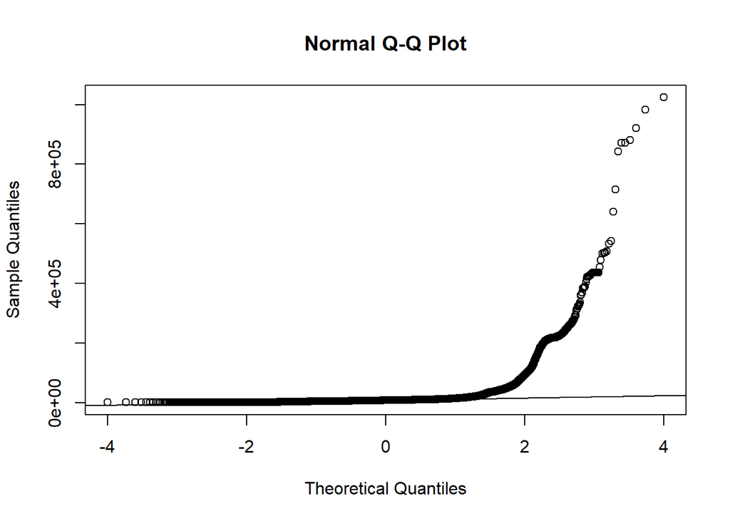

```r
qqnorm(trans_var$sqft_lot)
qqline(trans_var$sqft_lot)
```

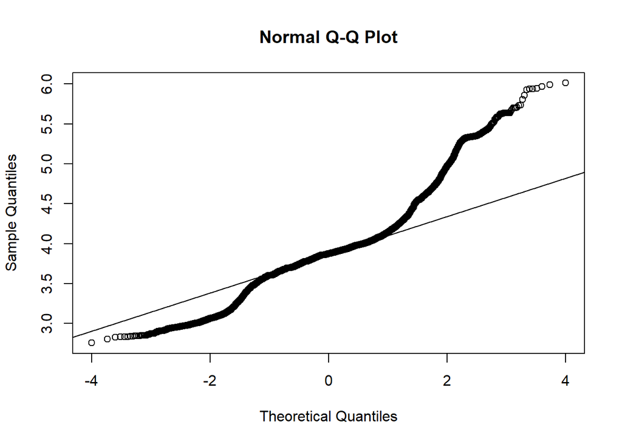

```r
qqnorm(trans_var$sqft_lot_trans)
qqline(trans_var$sqft_lot_trans)
```

Transformacion de **floors** a **dummie**, factor, y redondeamos hacia arriba

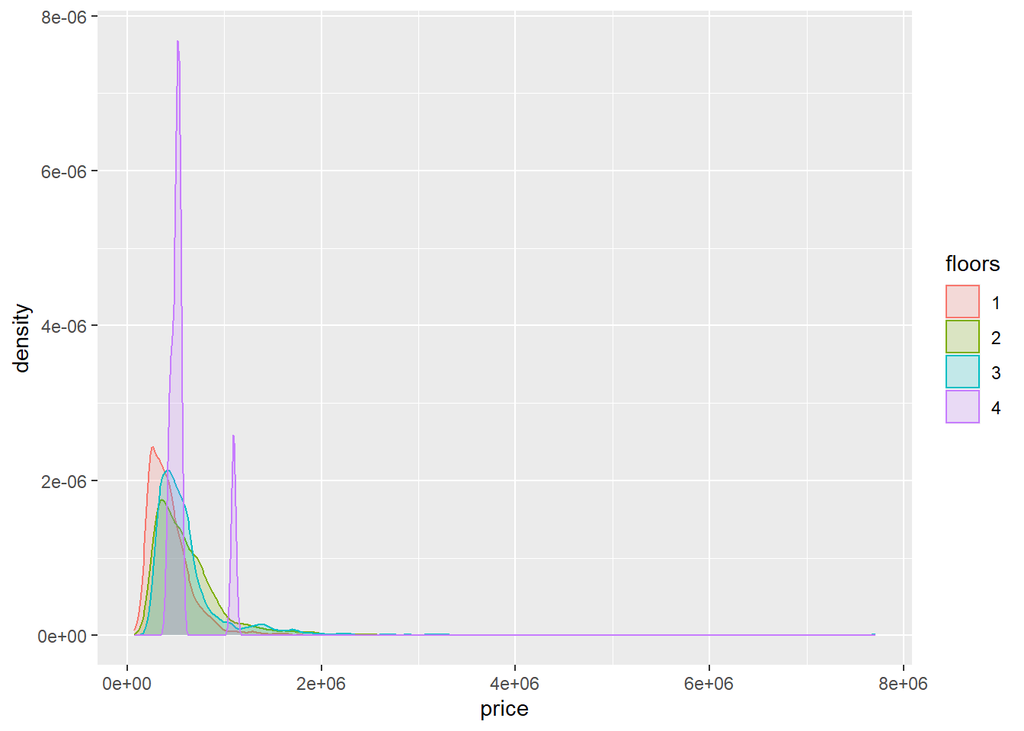

```r
#Transformacion floors, redondeamos arriba y transformamos a factor

df_floors <- trans_var[, c("price", "floors")]
df_floors$floors <- ceiling(df_floors$floors)
trans_var$floors= as.factor(df_floors$floors)
df_floors$floors= as.factor(df_floors$floors)
ggplot(df_floors, aes(x=price, color=floors, fill=floors)) + geom_density(alpha=.2)
```

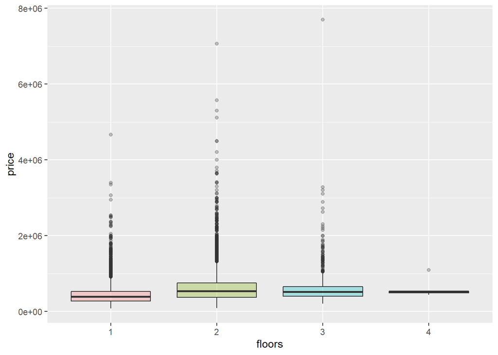

```r
ggplot(df_floors, aes(x=floors, y=price, fill=floors)) +  geom_boxplot(alpha=0.3) + theme(legend.position="none")
```

Transformacion de **waterfront** a **dummie** logical

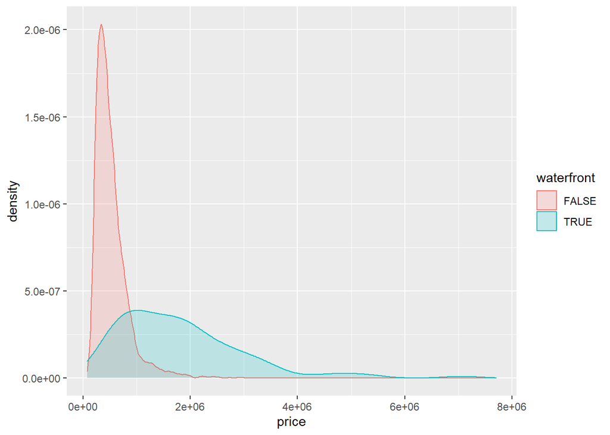

```r
#Transformacion waterfront a dummie, logical

trans_var$waterfront = as.logical(trans_var$waterfront)
df_waterfront <- trans_var[, c("price", "waterfront")]
ggplot(df_waterfront, aes(x=price, color=waterfront, fill=waterfront)) + geom_density(alpha=.2)
```

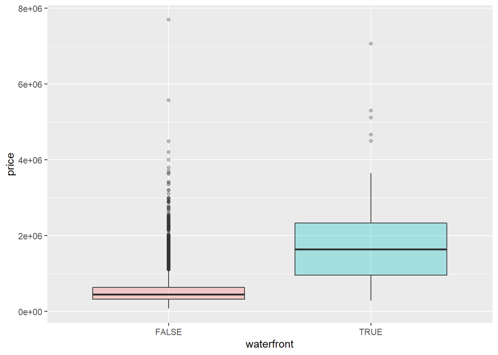

```r
ggplot(df_waterfront, aes(x=waterfront, y=price, fill=waterfront)) +  geom_boxplot(alpha=0.3) + theme(legend.position="none")
```

Transformacion de **view** a **dummie** factor

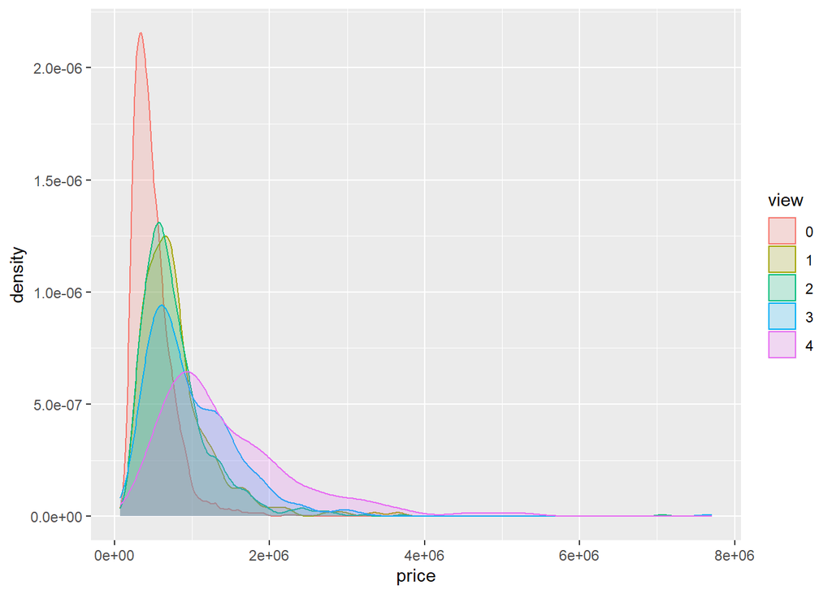

```r
#Transformacion view a dummie, factor

trans_var$view= as.factor(trans_var$view)
df_view <- trans_var[, c("price", "view")]
ggplot(df_view, aes(x=price, color=view, fill=view)) + geom_density(alpha=.2)
```

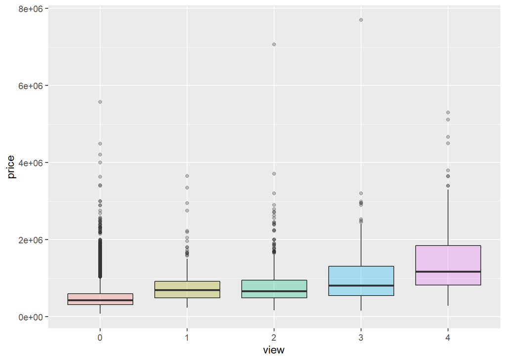

```r
ggplot(df_view, aes(x=view, y=price, fill=view)) +  geom_boxplot(alpha=0.3) + theme(legend.position="none")
```

Transformacion de **condition** a **dummie** factor

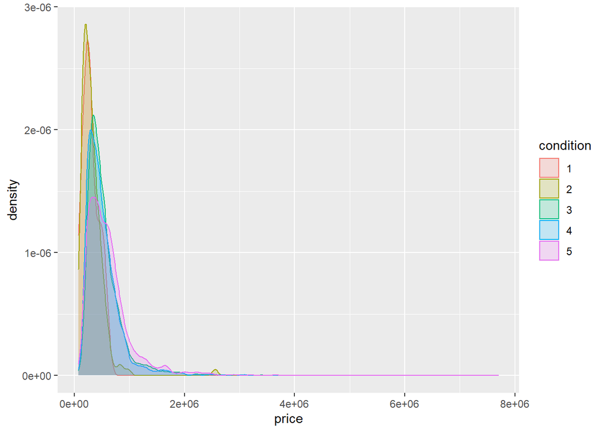

```r
#Transformacion condition a dummie, factor

trans_var$condition= as.factor(trans_var$condition)
df_condition <- trans_var[, c("price", "condition")]
ggplot(df_condition, aes(x=price, color=condition, fill=condition)) + geom_density(alpha=.2)
```

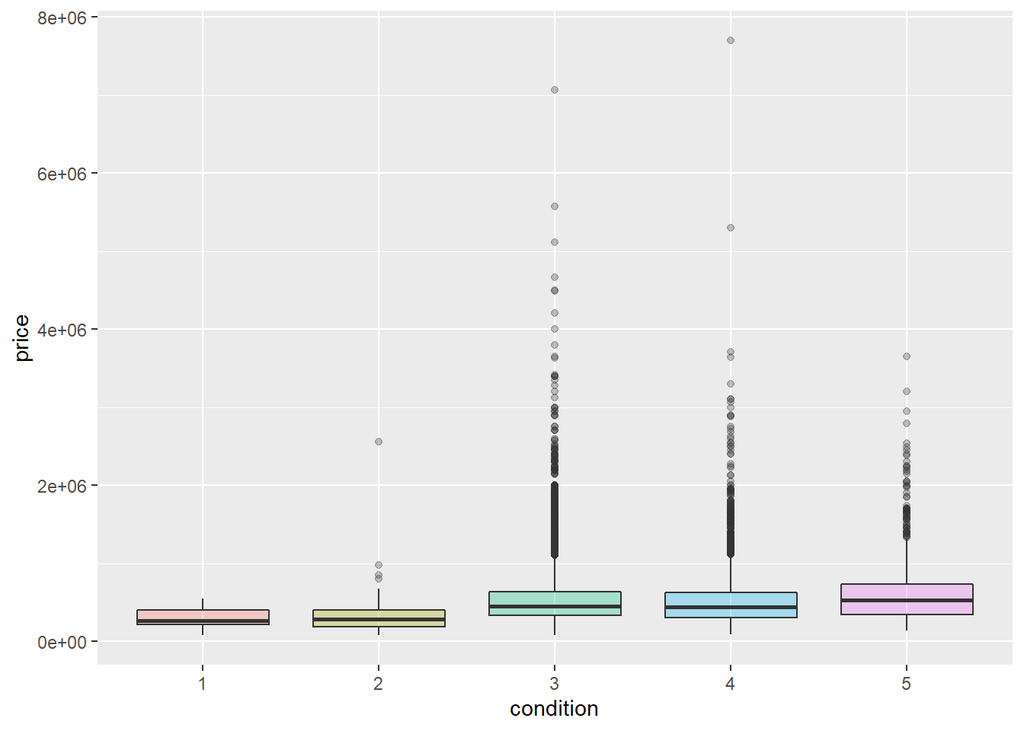

```r
ggplot(df_condition, aes(x=condition, y=price, fill=condition)) +  geom_boxplot(alpha=0.3) + theme(legend.position="none")
```

Transformacion de **grade** a **dummie** factor

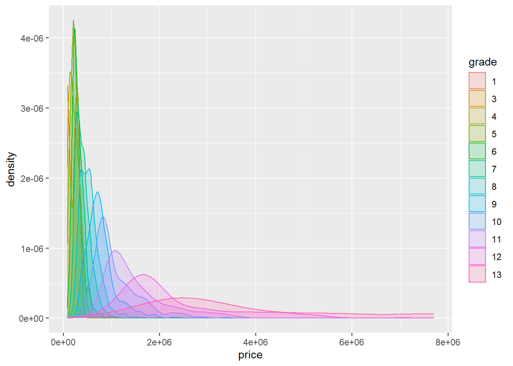

```r
#Transformacion grade a dummie, factor

trans_var$grade= as.factor(trans_var$grade)
df_grade <- trans_var[, c("price", "grade")]
ggplot(df_grade, aes(x=price, color=grade, fill=grade)) + geom_density(alpha=.2)
```

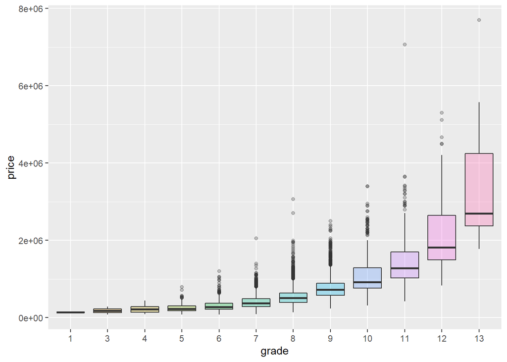

```r
ggplot(df_grade, aes(x=grade, y=price, fill=grade)) +  geom_boxplot(alpha=0.3) + theme(legend.position="none")
```

Transformacion de **sqft_above** con **log10**

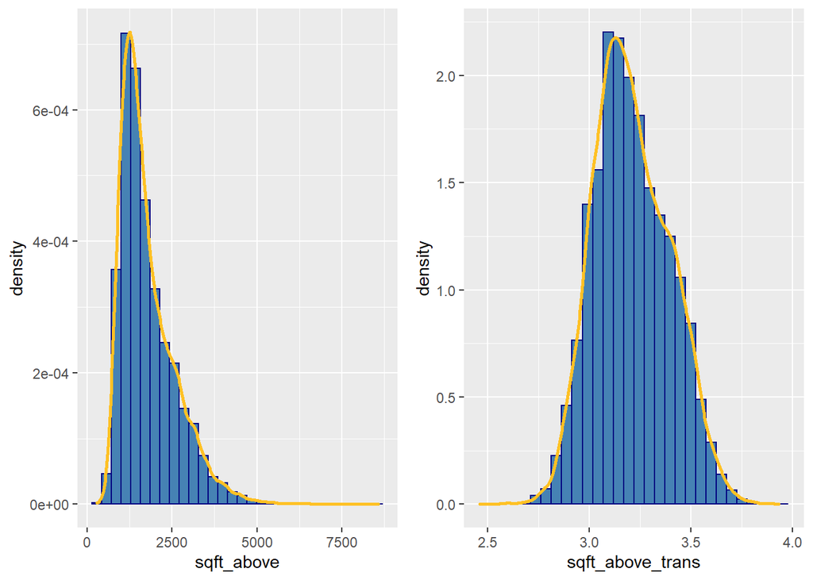

```r
#Transformacion sqft_above con log10

sqft_above_trans <- log10(trans_var$sqft_above)
trans_var <- mutate(train, sqft_above_trans)

p1 <- ggplot(trans_var, aes(x=sqft_above)) + geom_histogram(aes(y=..density..), colour = "navy", fill = "steelblue", bins=30) + geom_density(colour = "goldenrod1", size = 1)
p2 <- ggplot(trans_var, aes(x=sqft_above_trans)) + geom_histogram(aes(y=..density..), colour = "navy", fill = "steelblue", bins=30) + geom_density(colour = "goldenrod1", size = 1)
grid.arrange(p1, p2, nrow=1)
```

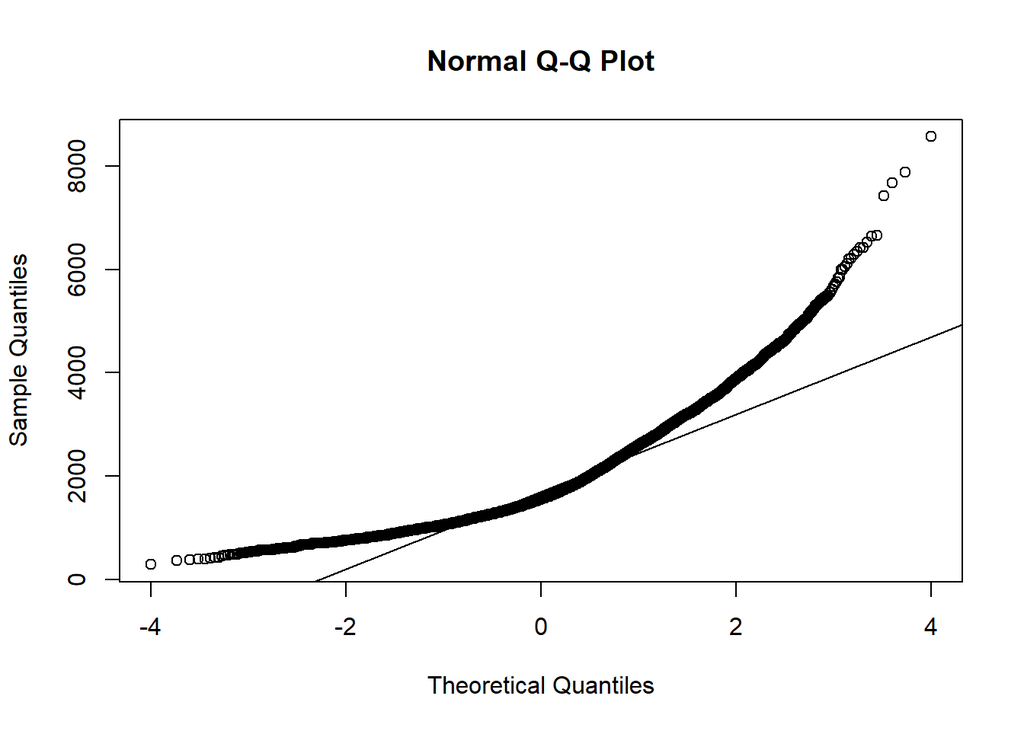

```r
qqnorm(trans_var$sqft_above)
qqline(trans_var$sqft_above)
```

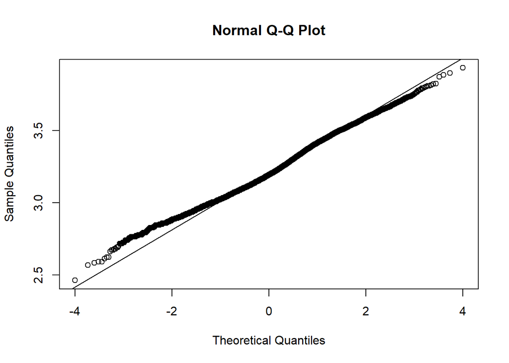

```r
qqnorm(trans_var$sqft_above_trans)
qqline(trans_var$sqft_above_trans)
```

Transformacion de **sqft_basement** a **dummie** logical

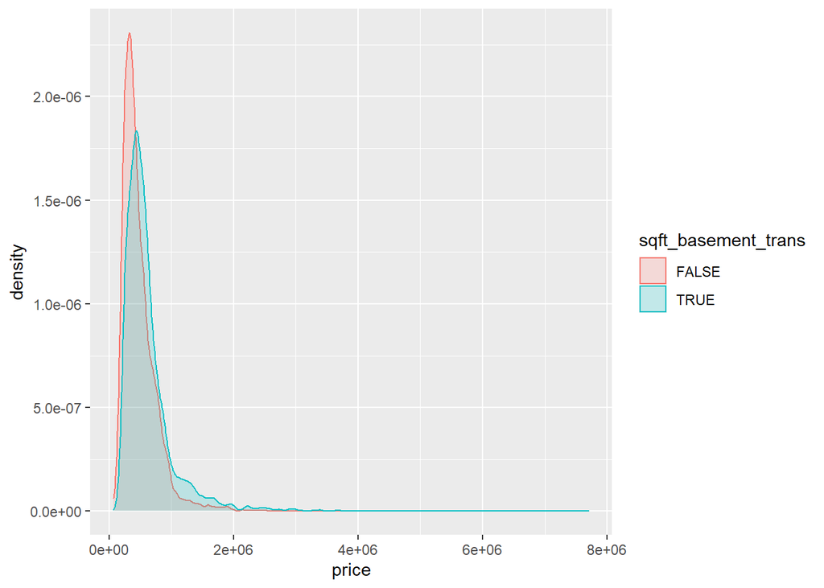

```r
#Transformacion sqft_basement a dummie, logical

sqft_basement_trans <- cut(trans_var$sqft_basement, breaks = c(-1, 1, Inf), labels = c("0", "1"), right = FALSE)
trans_var <- mutate(train, sqft_basement_trans)
trans_var$sqft_basement_trans= as.integer(trans_var$sqft_basement_trans)
trans_var$sqft_basement_trans= as.integer(trans_var$sqft_basement_trans-1)
trans_var$sqft_basement_trans= as.logical(trans_var$sqft_basement_trans)
df_sqft_basement_trans <- trans_var[, c("price", "sqft_basement_trans")]
ggplot(df_sqft_basement_trans, aes(x=price, color=sqft_basement_trans, fill=sqft_basement_trans)) + geom_density(alpha=.2)
```

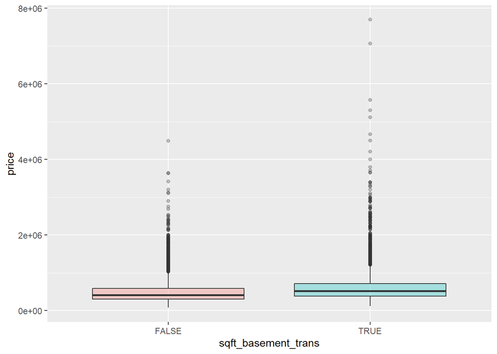

```r
ggplot(df_sqft_basement_trans, aes(x=sqft_basement_trans, y=price, fill=sqft_basement_trans)) +  geom_boxplot(alpha=0.3) + theme(legend.position="none")
```

Transformacion de **zipcode** a **dummie** factor

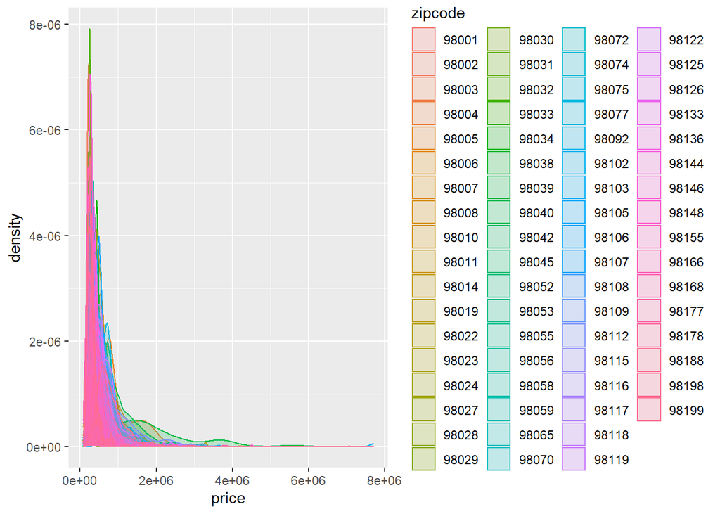

```r
#Transformacion zipcode a dummie, factor

trans_var$zipcode= as.factor(trans_var$zipcode)
df_zipcode <- trans_var[, c("price", "zipcode")]
ggplot(df_zipcode, aes(x=price, color=zipcode, fill=zipcode)) + geom_density(alpha=.2)
```

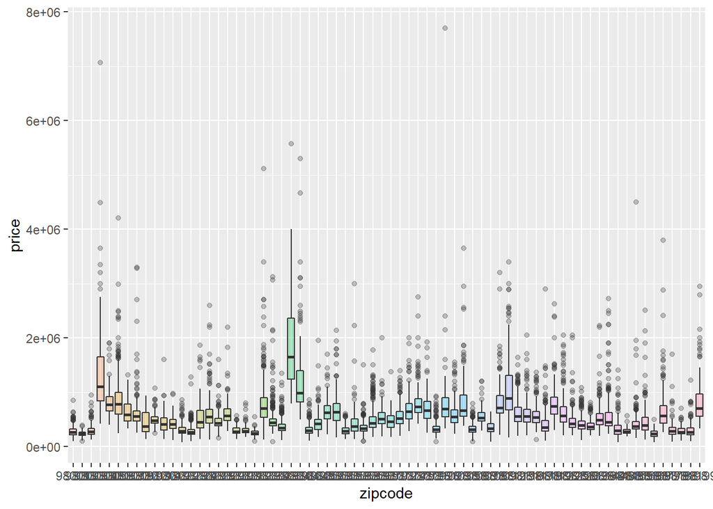

```r
ggplot(df_zipcode, aes(x=zipcode, y=price, fill=zipcode)) +  geom_boxplot(alpha=0.3) + theme(legend.position="none")
```

Transformacion de **sale_quarter** a **dummie** factor

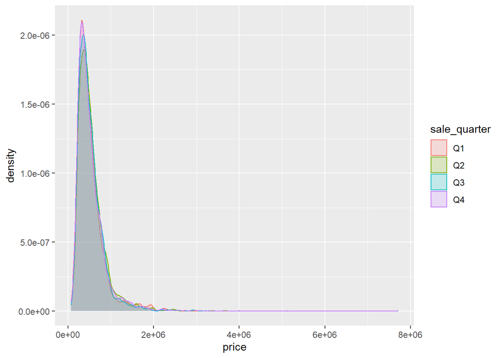

```r
#Transformacion sale_quarter a dummie, factor

trans_var$sale_quarter= as.factor(trans_var$sale_quarter)
df_sale_quarter <- trans_var[, c("price", "sale_quarter")]
ggplot(df_sale_quarter, aes(x=price, color=sale_quarter, fill=sale_quarter)) + geom_density(alpha=.2)
```

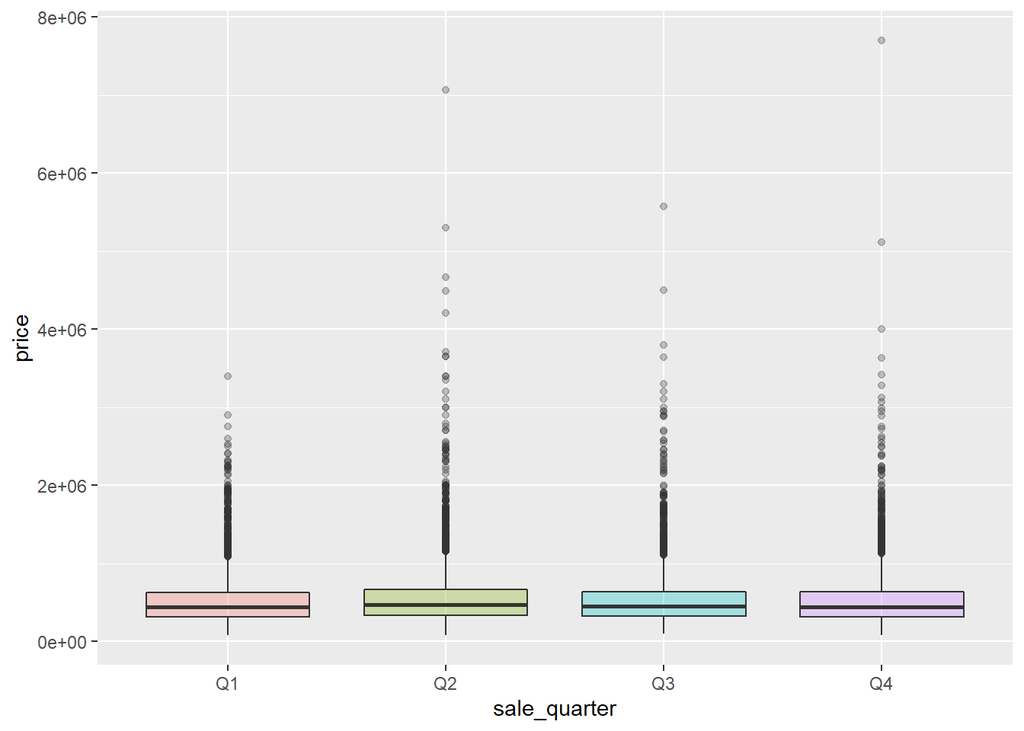

```r
ggplot(df_sale_quarter, aes(x=sale_quarter, y=price, fill=sale_quarter)) +  geom_boxplot(alpha=0.3) + theme(legend.position="none")
```

Transformacion de **Clusters** a **dummie** factor

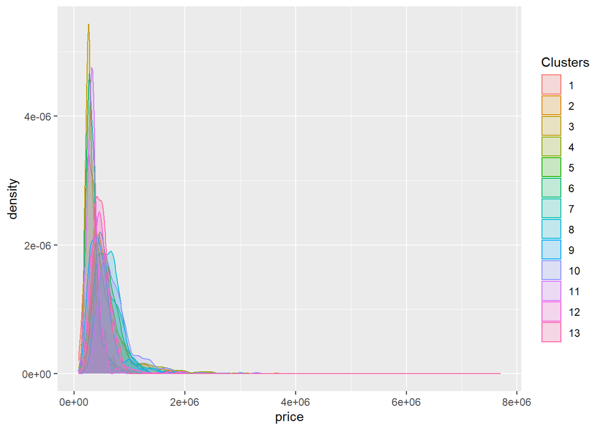

```r
#Transformacion Clusters a dummie, factor

trans_var$Clusters= as.factor(trans_var$Clusters)
df_Clusters <- trans_var[, c("price", "Clusters")]
ggplot(df_Clusters, aes(x=price, color=Clusters, fill=Clusters)) + geom_density(alpha=.2)
```

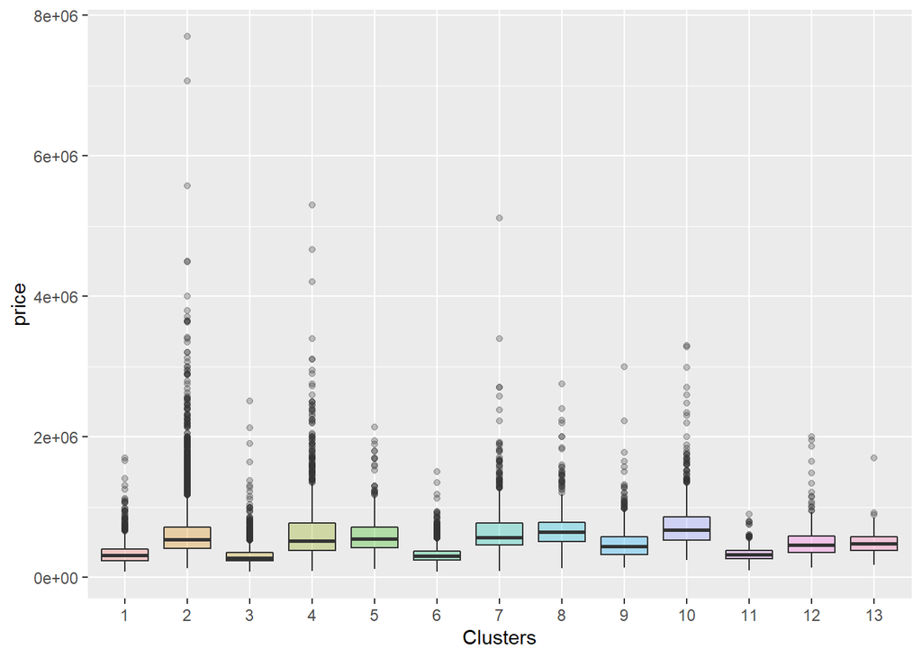

```r
ggplot(df_Clusters, aes(x=Clusters, y=price, fill=Clusters)) +  geom_boxplot(alpha=0.3) + theme(legend.position="none")
```

Transformacion de **sale_tenure** con **log10**

```r
#Transformacion sale_tenure con log10

sale_tenure_trans <- log10(trans_var$sale_tenure)
```

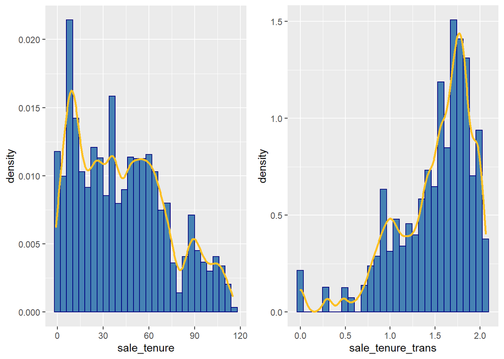

```r
trans_var <- mutate(train, sale_tenure_trans)

p1 <- ggplot(trans_var, aes(x=sale_tenure)) + geom_histogram(aes(y=..density..), colour = "navy", fill = "steelblue", bins=30) + geom_density(colour = "goldenrod1", size = 1)
p2 <- ggplot(trans_var, aes(x=sale_tenure_trans)) + geom_histogram(aes(y=..density..), colour = "navy", fill = "steelblue", bins=30) + geom_density(colour = "goldenrod1", size = 1)
grid.arrange(p1, p2, nrow=1)
```

Transformacion de **Dist_from_seattle** con **log10**

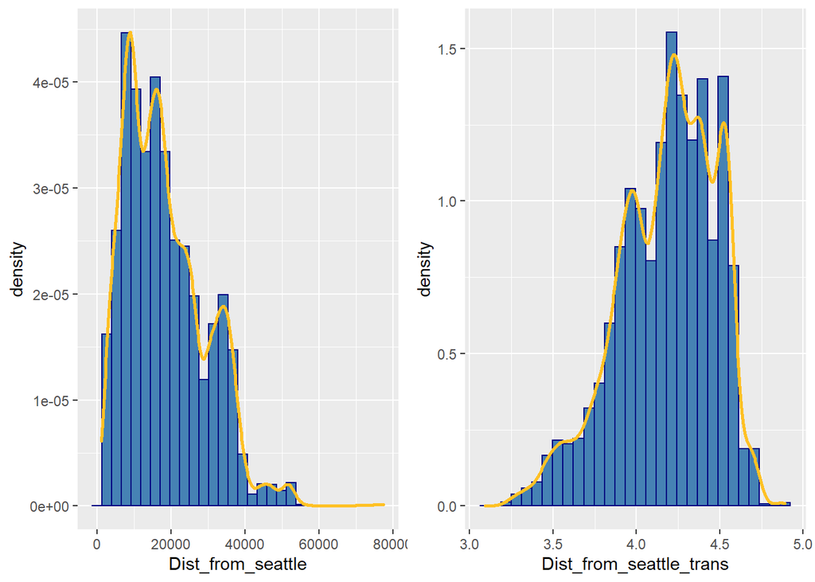

```r
#Transformacion Dist_from_seattle con log10

Dist_from_seattle_trans <- log10(trans_var$Dist_from_seattle)
trans_var <- mutate(train, Dist_from_seattle_trans)

p1 <- ggplot(trans_var, aes(x=Dist_from_seattle)) + geom_histogram(aes(y=..density..), colour = "navy", fill = "steelblue", bins=30) + geom_density(colour = "goldenrod1", size = 1)
p2 <- ggplot(trans_var, aes(x=Dist_from_seattle_trans)) + geom_histogram(aes(y=..density..), colour = "navy", fill = "steelblue", bins=30) + geom_density(colour = "goldenrod1", size = 1)
grid.arrange(p1, p2, nrow=1)
```

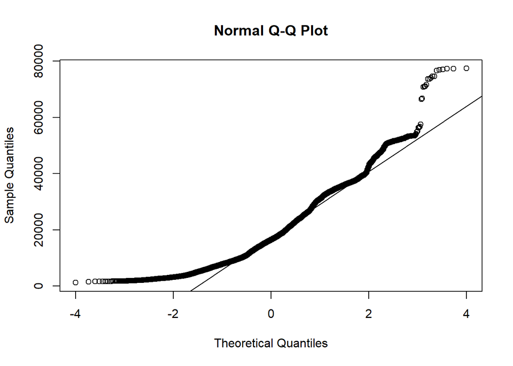

```r
qqnorm(trans_var$Dist_from_seattle)
qqline(trans_var$Dist_from_seattle)
```

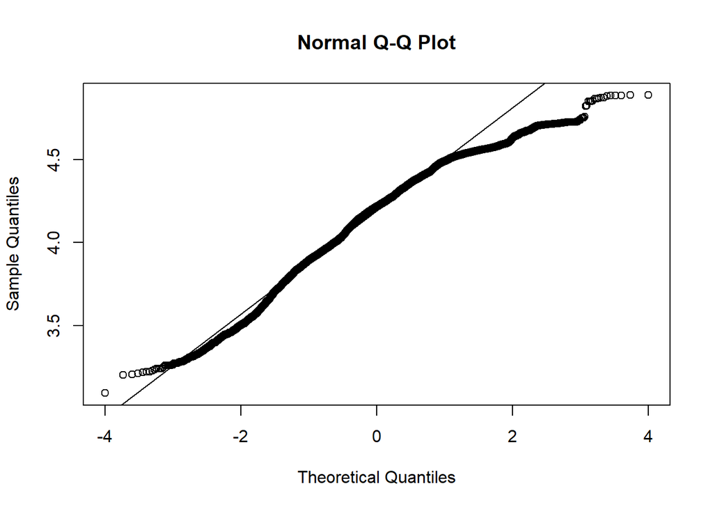

```r
qqnorm(trans_var$Dist_from_seattle_trans)
qqline(trans_var$Dist_from_seattle_trans)
```

Transformacion de **price_m2** con **log10**

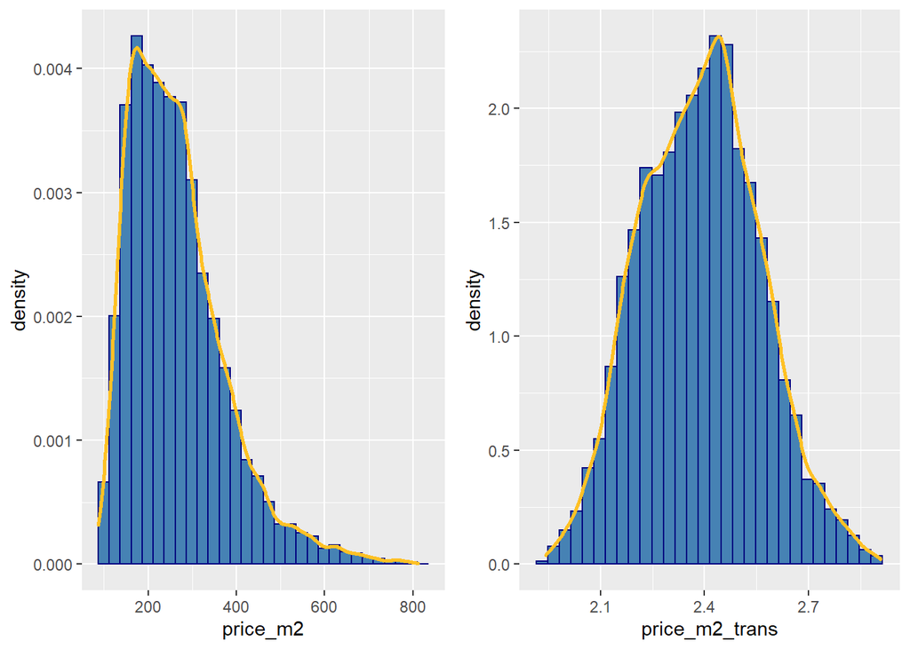

```r
#Transformacion price_m2 con log10

price_m2_trans <- log10(trans_var$price_m2)
trans_var <- mutate(train, price_m2_trans)

p1 <- ggplot(trans_var, aes(x=price_m2)) + geom_histogram(aes(y=..density..), colour = "navy", fill = "steelblue", bins=30) + geom_density(colour = "goldenrod1", size = 1)
p2 <- ggplot(trans_var, aes(x=price_m2_trans)) + geom_histogram(aes(y=..density..), colour = "navy", fill = "steelblue", bins=30) + geom_density(colour = "goldenrod1", size = 1)
grid.arrange(p1, p2, nrow=1)
```

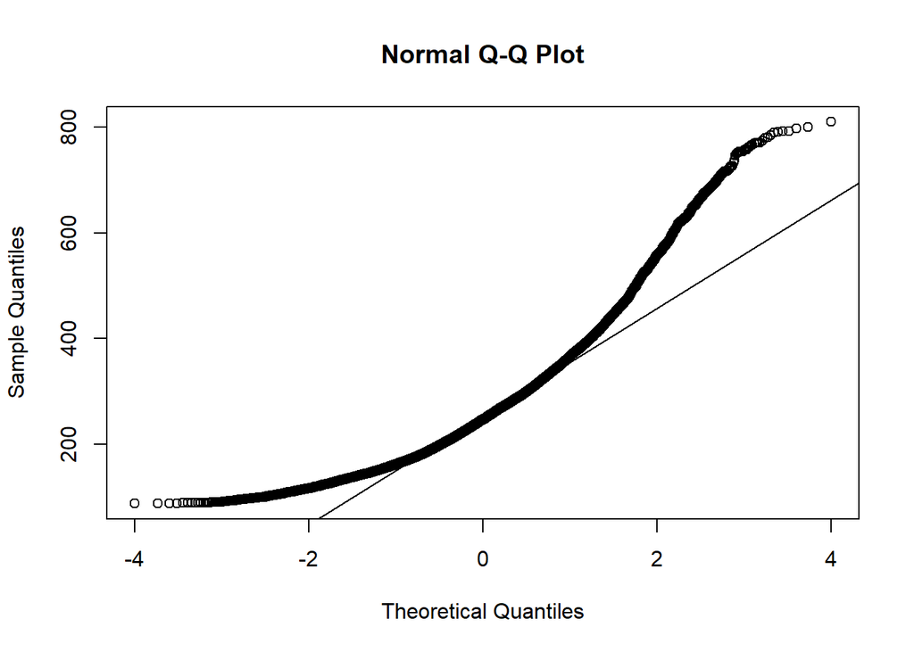

```r
qqnorm(trans_var$price_m2)
qqline(trans_var$price_m2)
```

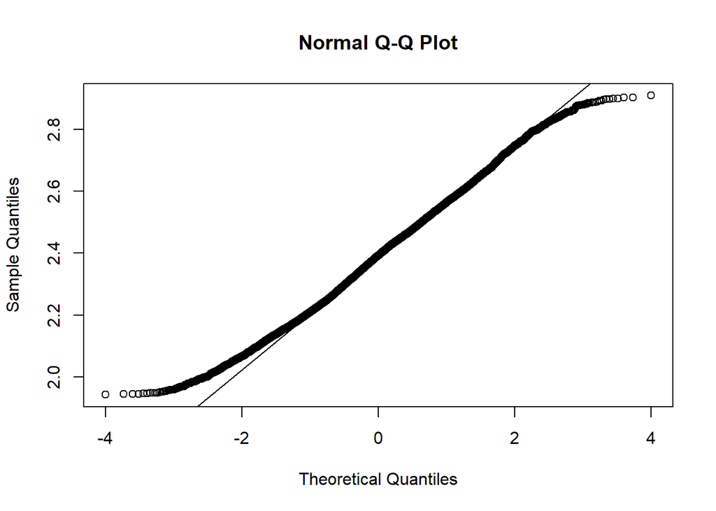

```r
qqnorm(trans_var$price_m2_trans)
qqline(trans_var$price_m2_trans)
```

### Resumen Transformaciones

- Transformacion de **price** con **log10**
- Transformacion de **bedrooms** a **dummie**, factor, y quitamos el 33
- Transformacion de **bathrooms** a **dummie**, factor, y redondeamos hacia arriba
- Transformacion de **sqft_living** con **log10**
- Transformacion de **sqft_lot** con **log10**
- Transformacion de **floors** a **dummie**, factor, y redondeamos hacia arriba
- Transformacion de **waterfront** a **dummie** logical
- Transformacion de **view** a **dummie** factor
- Transformacion de **condition** a **dummie** factor
- Transformacion de **grade** a **dummie** factor
- Transformacion de **sqft_above** con **log10**
- Transformacion de **sqft_basement** a **dummie** logical
- Transformacion de **zipcode** a **dummie** factor
- Transformacion de **sale_quarter** a **dummie** factor
- Transformacion de **Clusters** a **dummie** factor
- Transformacion de **sale_tenure** con **log10**
- Transformacion de **Dist_from_seattle** con **log10**
- Transformacion de **price_m2** con **log10**

```r
#Tranfomación de variables

train$waterfront = as.factor(train$waterfront)
train$view = as.factor(train$view)
train$zipcode = as.factor(train$zipcode)


#Creamos una variable que mide la distnacia de cada casa a la venta con respecto al centro ecónomico de la ciudad: Seattle
seattle = c(-122.335167, 47.608013)
train = mutate(train, Dist_from_seattle=distHaversine(cbind(long, lat),seattle))

#POr otro lado, se calcula la distancia de cada casa con respecto al resto, agrupando después casas cercanas en clústers.
long= train$long
lat = train$lat
DataMat<-as.matrix(cbind(long, lat))
DataMat[is.na(DataMat)]<-0

my_data <- as_tibble(DataMat)
#my_data=my_data %>% slice(1:100)
my_data = as.data.frame(my_data)

#<-distm(my_data,my_data,fun=distHaversine)/1000
#hclustfunc <- function(x) hclust(x, method="complete")
#distfunc <- function(x) as.dist((1-cor(t(x)))/2)
#d <- distfunc(Dist_Mat)
#fit <- hclustfunc(d)
#my_data$Clusters<- cutree(fit, h=0.25)
#train = merge(x = train, y = my_data, by = c("lat", "long") , all.x = TRUE)
#train$Clusters = as.factor(train$Clusters)
#bwplot(Clusters~price, data = train, horizontal= TRUE)




#specify_decimal
specify_decimal <- function(x, k) format(round(x, k), nsmall=k)

#beautifying summary.lm
new_summary  <- function(lmcoef, digits) {

  coefs <- as.data.frame(lmcoef)
  coefs[] <- lapply(coefs, function(x) specify_decimal(x, digits))
  coefs

}


#(train, file = "C:/Users/Moncef/Documents/house_king_county/train.csv")

#Convertimos las variables catageoricas en dummies para su uso en el modelo.

# train_v1<- dummy_cols(train, select_columns = c('waterfront','view','Clusters','sale_quarter'),remove_most_frequent_dummy = TRUE,
#                    remove_selected_columns = TRUE)
#
# train_v1$sqft_lot_log = log(train_v1$sqft_lot)
# train_v1$sqft_above_log = log(train_v1$sqft_above)
# train_v1$sqft_living_log = log(train_v1$sqft_living)
# train_v1$Dist_from_seattle_log = log(train_v1$Dist_from_seattle)
# #train_v1$yr_renovated_log = log(train_v1$yr_renovated)
# #train_v1$sale_tenure_log = log(train_v1$sale_tenure)
#
#
# #Incluimos en c() las variables que NO queremos usar en la regresión.
# train_v2 = dplyr::select(train_v1,-c(id,sale_tenure,yr_renovated,sqft_above,sqft_lot,sale_tenure,yr_renovated,sqft_living,Dist_from_seattle,price,date,zipcode,sqft_basement,lat,sqft_lot15,long,date,sale_date,
#                               sale_year,yr_built,sale_month,yr_since_last_renovated,sqft_living15))
#
# summarize(train_v2)
#
# model <- lm(log(price_m2) ~ ., data = train_v2)
# summary(model)
# new_summary(summary(model)$coefficients, 5)
#
# plot(model, 1)
# res <- resid(model)
# plot(fitted(model), res)
# plot(model, which=1, col=c("blue"))
# plot(model, 2)
#
# require(nortest)  # Se debe haber instalado nortest
# lillie.test(model$residuals)
```

## ANÁLISIS DEL MODELO

- Modelo inicial con la variable respuesta “price”: se trata del modelo con la variable original “price” y sin las variables “Cluster” y “Dist_from_Seattle”. Es un modelo inicial de partida para ver como mejora o empeora el R2 al añadir nuevas variables o una transformación de la variable respuesta.
- Modelo con la variables respuesta “log_price_m2” : en este modelo utilizamos la variable respuesta dividida por los metros cuadrados con el objetivo de estabilizar la variable “price”, variable con mucha dispersión.
- Modelo con la variables respuesta sugeridas por la regresión LASSO : en este modelo utilizamos de nuevo la variable respuesta dividida por los metros cuadrados, siendo las variables explicativas aquellas seleccionadas por la regresión LASSO.
- Modelo con la variables respuesta sugeridas por su capacidad de reducción del AIC : en este modelo utilizamos de nuevo la variable respuesta dividida por los metros cuadrados, siendo las variables explicativas aquellas que mayor aportación tienen en términos de reducción del AIC.

```r
#train <- as.data.frame(read.csv(file = 'C:/Users/n0375471/OneDrive - Liberty Mutual/Documentos/house_king_county/house_king_county-Moncef/train.csv'))
```

### Modelo inicial con la variable respuesta “price”.

Estimamos el modelo con la variable original “price” y sin las variables “Cluster” y “Dist_from_Seattle”. Es un modelo inicial de partida para ver como mejora o empeora el R2 al añadir nuevas variables o una transformación de la variable respuesta:

```r
#Incluimos en c() las variables que NO queremos usar en la regresiÃ³n.
train_v2 = dplyr::select(train_v1,-c(id,sale_tenure,yr_renovated,sqft_above,sqft_lot,sale_tenure,
                                     yr_renovated,sqft_living,Dist_from_seattle,date,zipcode,sqft_basement,lat,sqft_lot15,long,date,sale_date,
                                     sale_year,yr_built,sale_month,yr_since_last_renovated,sqft_living15,price_m2,Dist_from_seattle_log,
                                     Clusters_1,
Clusters_3,
Clusters_4,
Clusters_5,
Clusters_6,
Clusters_7,
Clusters_8,
Clusters_9,
Clusters_10,
Clusters_11,
Clusters_12,
Clusters_13,
Clusters_8))

model_inicial <- lm(price ~ ., data = train_v2)
summary(model_inicial)
```

```
##
## Call:
## lm(formula = price ~ ., data = train_v2)
##
## Residuals:
##      Min       1Q   Median       3Q      Max
## -1130052  -130029   -22972    96175  5750872
##
## Coefficients:
##                 Estimate Std. Error t value Pr(>|t|)
## (Intercept)     -2005108      53878 -37.216  < 2e-16 ***
## bedrooms          -10557       2651  -3.982 6.86e-05 ***
## bathrooms          29684       4201   7.066 1.66e-12 ***
## floors            -41868       5259  -7.961 1.82e-15 ***
## condition          55517       3076  18.051  < 2e-16 ***
## grade             143227       2682  53.393  < 2e-16 ***
## waterfront_1      680297      28345  24.000  < 2e-16 ***
## view_1            156199      15626   9.996  < 2e-16 ***
## view_2            120676       9426  12.803  < 2e-16 ***
## view_3            197597      12942  15.268  < 2e-16 ***
## view_4            327014      20521  15.935  < 2e-16 ***
## sale_quarter_Q1    -6593       5482  -1.203  0.22916
## sale_quarter_Q3   -23366       4935  -4.734 2.22e-06 ***
## sale_quarter_Q4   -15243       5258  -2.899  0.00375 **
## sqft_lot_log      -19384       2642  -7.336 2.31e-13 ***
## sqft_above_log    -11671      11295  -1.033  0.30146
## sqft_living_log   204570      11935  17.140  < 2e-16 ***
## ---
## Signif. codes:  0 '***' 0.001 '**' 0.01 '*' 0.05 '.' 0.1 ' ' 1
##
## Residual standard error: 238900 on 15961 degrees of freedom
##   (1 observation deleted due to missingness)
## Multiple R-squared:  0.5621, Adjusted R-squared:  0.5617
## F-statistic:  1281 on 16 and 15961 DF,  p-value: < 2.2e-16
```

```r
new_summary(summary(model_inicial )$coefficients, 5)
```

```
##                       Estimate  Std. Error   t value Pr(>|t|)
## (Intercept)     -2005108.41635 53877.54352 -37.21603  0.00000
## bedrooms          -10557.05037  2651.10365  -3.98213  0.00007
## bathrooms          29683.86668  4200.74645   7.06633  0.00000
## floors            -41867.54733  5259.17115  -7.96086  0.00000
## condition          55516.92030  3075.50404  18.05132  0.00000
## grade             143227.15078  2682.50782  53.39300  0.00000
## waterfront_1      680296.83531 28345.44604  24.00022  0.00000
## view_1            156199.36707 15625.69315   9.99632  0.00000
## view_2            120675.50961  9425.57831  12.80298  0.00000
## view_3            197597.00770 12942.06993  15.26781  0.00000
## view_4            327013.75827 20521.17804  15.93543  0.00000
## sale_quarter_Q1    -6592.68582  5482.21171  -1.20256  0.22916
## sale_quarter_Q3   -23365.84986  4935.29928  -4.73443  0.00000
## sale_quarter_Q4   -15242.56412  5258.25979  -2.89878  0.00375
## sqft_lot_log      -19383.97887  2642.47335  -7.33554  0.00000
## sqft_above_log    -11671.38631 11294.80188  -1.03334  0.30146
## sqft_living_log   204570.31332 11935.23742  17.14003  0.00000
```

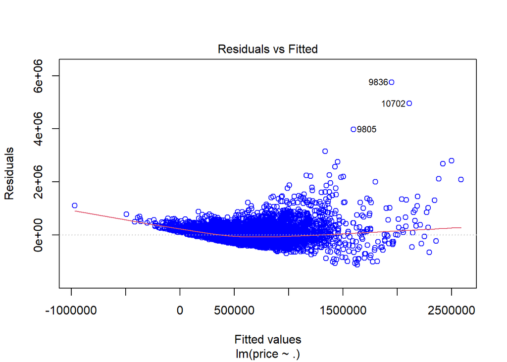

```r
plot(model_inicial , which=1, col=c("blue"))
```

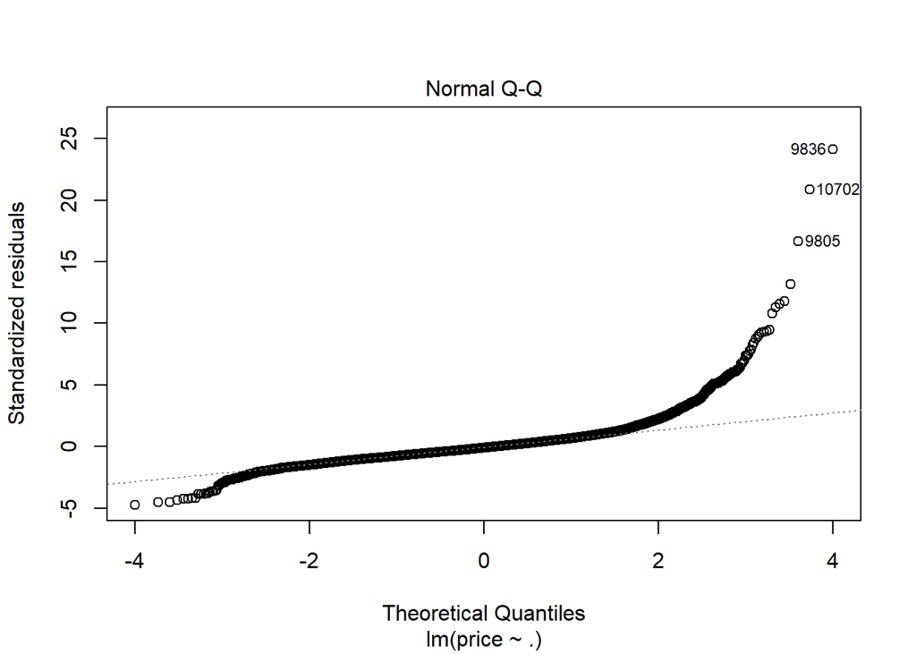

```r
plot(model_inicial , 2)
```

```r
#Test bondad del auste para los residuos

require(nortest)  # Se debe haber instalado nortest
(lillie.test(model_inicial $residuals))
```

```
##
##  Lilliefors (Kolmogorov-Smirnov) normality test
##
## data:  model_inicial$residuals
## D = 0.096568, p-value < 2.2e-16
```

### Modelo con la variables respuesta “log_price_m2”

En este apartado estimamos un modelo con la variables respuesta “log_price_m2”. Para este modelo utilizamos la variable respuesta dividida por los metros cuadrados con el objetivo de estabilizar la variable “price”, la cual presenta una gran dispersión.

```r
#Incluimos en c() las variables que NO queremos usar en la regresiÃ³n.
train_v2 = dplyr::select(train_v1,-c(id,sale_tenure,yr_renovated,sqft_above,sqft_lot,sale_tenure,yr_renovated,sqft_living,Dist_from_seattle,price,date,zipcode,sqft_basement,lat,sqft_lot15,long,date,sale_date,
                              sale_year,yr_built,sale_month,yr_since_last_renovated,sqft_living15))


model <- lm(log(price_m2) ~ ., data = train_v2)
summary(model)
```

```
##
## Call:
## lm(formula = log(price_m2) ~ ., data = train_v2)
##
## Residuals:
##      Min       1Q   Median       3Q      Max
## -1.35754 -0.12279  0.00067  0.12023  1.19814
##
## Coefficients:
##                        Estimate Std. Error t value Pr(>|t|)
## (Intercept)           10.445231   0.064207 162.681  < 2e-16 ***
## bedrooms              -0.019805   0.002364  -8.379  < 2e-16 ***
## bathrooms              0.041827   0.003760  11.123  < 2e-16 ***
## floors                -0.040243   0.004733  -8.502  < 2e-16 ***
## condition              0.066527   0.002773  23.995  < 2e-16 ***
## grade                  0.118457   0.002468  47.988  < 2e-16 ***
## waterfront_1           0.502288   0.025164  19.961  < 2e-16 ***
## view_1                 0.199151   0.013912  14.315  < 2e-16 ***
## view_2                 0.110850   0.008423  13.160  < 2e-16 ***
## view_3                 0.181225   0.011540  15.704  < 2e-16 ***
## view_4                 0.252350   0.018263  13.817  < 2e-16 ***
## Clusters_1            -0.364374   0.007102 -51.309  < 2e-16 ***
## Clusters_3            -0.395382   0.008084 -48.911  < 2e-16 ***
## Clusters_4            -0.147517   0.006635 -22.234  < 2e-16 ***
## Clusters_5             0.014898   0.010136   1.470  0.14164
## Clusters_6            -0.297717   0.009019 -33.009  < 2e-16 ***
## Clusters_7             0.017017   0.007483   2.274  0.02297 *
## Clusters_8             0.095547   0.009701   9.850  < 2e-16 ***
## Clusters_9            -0.228905   0.010497 -21.806  < 2e-16 ***
## Clusters_10            0.042105   0.008993   4.682 2.86e-06 ***
## Clusters_11           -0.361475   0.010082 -35.852  < 2e-16 ***
## Clusters_12            0.035516   0.013037   2.724  0.00645 **
## Clusters_13           -0.152660   0.016542  -9.228  < 2e-16 ***
## sale_quarter_Q1        0.002108   0.004860   0.434  0.66444
## sale_quarter_Q3       -0.036056   0.004375  -8.241  < 2e-16 ***
## sale_quarter_Q4       -0.036445   0.004661  -7.820 5.63e-15 ***
## sqft_lot_log           0.071951   0.002593  27.752  < 2e-16 ***
## sqft_above_log         0.193758   0.010436  18.566  < 2e-16 ***
## sqft_living_log       -0.678706   0.010748 -63.148  < 2e-16 ***
## Dist_from_seattle_log -0.297930   0.005170 -57.623  < 2e-16 ***
## ---
## Signif. codes:  0 '***' 0.001 '**' 0.01 '*' 0.05 '.' 0.1 ' ' 1
##
## Residual standard error: 0.2116 on 15948 degrees of freedom
##   (1 observation deleted due to missingness)
## Multiple R-squared:  0.7119, Adjusted R-squared:  0.7114
## F-statistic:  1359 on 29 and 15948 DF,  p-value: < 2.2e-16
```

```r
new_summary(summary(model)$coefficients, 5)
```

```
##                       Estimate Std. Error   t value Pr(>|t|)
## (Intercept)           10.44523    0.06421 162.68098  0.00000
## bedrooms              -0.01980    0.00236  -8.37875  0.00000
## bathrooms              0.04183    0.00376  11.12308  0.00000
## floors                -0.04024    0.00473  -8.50248  0.00000
## condition              0.06653    0.00277  23.99461  0.00000
## grade                  0.11846    0.00247  47.98792  0.00000
## waterfront_1           0.50229    0.02516  19.96096  0.00000
## view_1                 0.19915    0.01391  14.31528  0.00000
## view_2                 0.11085    0.00842  13.15997  0.00000
## view_3                 0.18122    0.01154  15.70408  0.00000
## view_4                 0.25235    0.01826  13.81728  0.00000
## Clusters_1            -0.36437    0.00710 -51.30877  0.00000
## Clusters_3            -0.39538    0.00808 -48.91129  0.00000
## Clusters_4            -0.14752    0.00663 -22.23448  0.00000
## Clusters_5             0.01490    0.01014   1.46978  0.14164
## Clusters_6            -0.29772    0.00902 -33.00937  0.00000
## Clusters_7             0.01702    0.00748   2.27408  0.02297
## Clusters_8             0.09555    0.00970   9.84965  0.00000
## Clusters_9            -0.22891    0.01050 -21.80597  0.00000
## Clusters_10            0.04210    0.00899   4.68215  0.00000
## Clusters_11           -0.36147    0.01008 -35.85202  0.00000
## Clusters_12            0.03552    0.01304   2.72425  0.00645
## Clusters_13           -0.15266    0.01654  -9.22848  0.00000
## sale_quarter_Q1        0.00211    0.00486   0.43379  0.66444
## sale_quarter_Q3       -0.03606    0.00437  -8.24140  0.00000
## sale_quarter_Q4       -0.03644    0.00466  -7.81950  0.00000
## sqft_lot_log           0.07195    0.00259  27.75212  0.00000
## sqft_above_log         0.19376    0.01044  18.56572  0.00000
## sqft_living_log       -0.67871    0.01075 -63.14755  0.00000
## Dist_from_seattle_log -0.29793    0.00517 -57.62254  0.00000
```

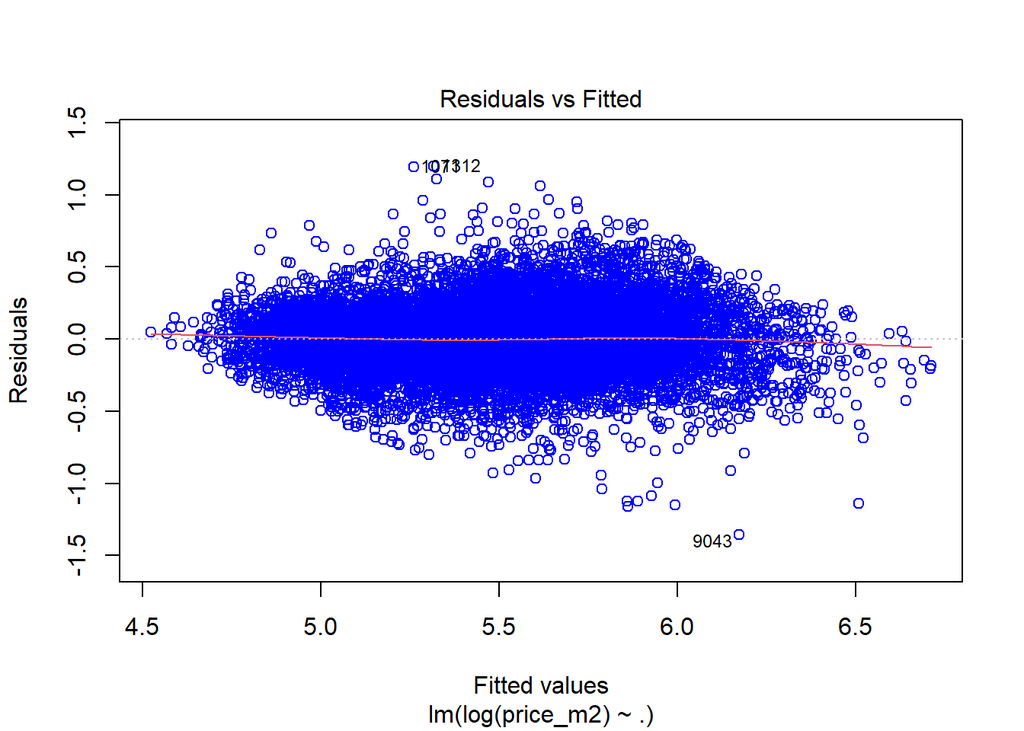

```r
plot(model, which=1, col=c("blue"))
```

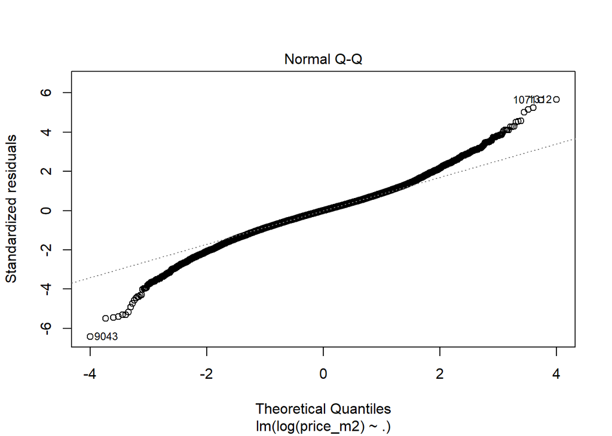

```r
plot(model, 2)
```

```r
require(nortest)  # Se debe haber instalado nortest
lillie.test(model$residuals)
```

```
##
##  Lilliefors (Kolmogorov-Smirnov) normality test
##
## data:  model$residuals
## D = 0.035679, p-value < 2.2e-16
```

```r
#Test bondad del auste para los residuos del modelo con log_price_m2

require(nortest)  # Se debe haber instalado nortest
(lillie.test(model $residuals))
```

```
##
##  Lilliefors (Kolmogorov-Smirnov) normality test
##
## data:  model$residuals
## D = 0.035679, p-value < 2.2e-16
```

En este segundo modelo, podemos ver que el R2 ajustado es del 71%, 14% puntos mayor al modelo inicial. Por otra parte, el grafico de los residuos no muestra una tendencía como el modelo anterior y parece que los residuos fluctuan alrededor de la media, siendo la varianza relativamente constante.

No obstante, tanto el Q-Q plot como el test de bondad de ajuste realizado sobre los residuos nos hacen rechazar la hipótesis nula de normalidad de los residuos.

### Modelo con la variables respuesta sugeridas por la regresión LASSO

Para este modelo utilizamos de nuevo la variable respuesta dividida por los metros cuadrados, siendo las variables explicativas aquellas seleccionadas por la regresión LASSO.

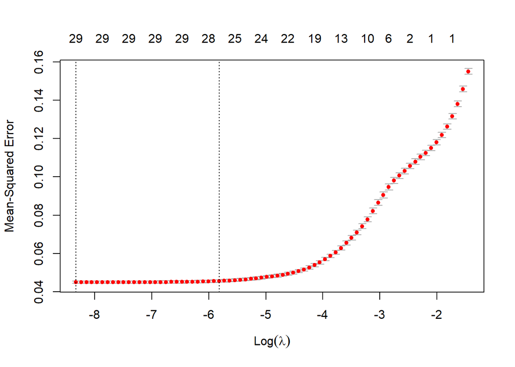

```r
# Ajuste de la funciÃ³n de error
cv_lasso <- cv.glmnet(x = lambdas, y = y, alpha = 1)
plot(cv_lasso)
```

```r
out_eleven <- glmnet(lambdas,y,alpha=1,lambda = cv_lasso$lambda.1se)
out_eleven
```

```
##
## Call:  glmnet(x = lambdas, y = y, alpha = 1, lambda = cv_lasso$lambda.1se)
##
##   Df  %Dev   Lambda
## 1 27 70.78 0.002965
```

```r
coef(out_eleven )
```

```
## 31 x 1 sparse Matrix of class "dgCMatrix"
##                                 s0
## (Intercept)           10.111961836
## (Intercept)            .
## bedrooms              -0.018255033
## bathrooms              0.017471611
## floors                -0.008505463
## condition              0.059250478
## grade                  0.117448544
## waterfront_1           0.481999639
## view_1                 0.165708131
## view_2                 0.091934653
## view_3                 0.156851173
## view_4                 0.230247640
## Clusters_1            -0.346824456
## Clusters_3            -0.392590891
## Clusters_4            -0.123133875
## Clusters_5             .
## Clusters_6            -0.299602763
## Clusters_7             0.007827504
## Clusters_8             0.074397657
## Clusters_9            -0.206720020
## Clusters_10            0.033253230
## Clusters_11           -0.348330134
## Clusters_12            0.003728593
## Clusters_13           -0.134183644
## sale_quarter_Q1        .
## sale_quarter_Q3       -0.026172212
## sale_quarter_Q4       -0.027540964
## sqft_lot_log           0.067888713
## sqft_above_log         0.097163739
## sqft_living_log       -0.560975451
## Dist_from_seattle_log -0.274727582
```

```r
cv_lasso
```

```
##
## Call:  cv.glmnet(x = lambdas, y = y, alpha = 1)
##
## Measure: Mean-Squared Error
##
##        Lambda Index Measure        SE Nonzero
## min 0.0002405    75 0.04496 0.0006235      29
## 1se 0.0029645    48 0.04558 0.0006876      27
```

```r
# Test de normalidad de residuos
preds_lasso <- predict(out_eleven,lambdas)
residuals_lasso <- y - preds_lasso
lillie.test(residuals_lasso)
```

```
##
##  Lilliefors (Kolmogorov-Smirnov) normality test
##
## data:  residuals_lasso
## D = 0.03904, p-value < 2.2e-16
```

```r
rsq_lasso <- cor(y, preds_lasso)^2
sprintf("R2 = %f", rsq_lasso)
```

```
## [1] "R2 = 0.708846"
```

### Modelo con la variables respuesta sugeridas por su capacidad de reducción del AIC

En este modelo utilizamos de nuevo la variable respuesta dividida por los metros cuadrados, siendo las variables explicativas aquellas que mayor aportación tienen en términos de reducción del AIC.

```r
#Analisis de variables candidatas
step_model <- stepAIC(model, trace = TRUE, direction= "both")
```

```
## Start:  AIC=-49593.67
## log(price_m2) ~ bedrooms + bathrooms + floors + condition + grade +
##     waterfront_1 + view_1 + view_2 + view_3 + view_4 + Clusters_1 +
##     Clusters_3 + Clusters_4 + Clusters_5 + Clusters_6 + Clusters_7 +
##     Clusters_8 + Clusters_9 + Clusters_10 + Clusters_11 + Clusters_12 +
##     Clusters_13 + sale_quarter_Q1 + sale_quarter_Q3 + sale_quarter_Q4 +
##     sqft_lot_log + sqft_above_log + sqft_living_log + Dist_from_seattle_log
##
##                         Df Sum of Sq    RSS    AIC
## - sale_quarter_Q1        1     0.008 714.34 -49595
## <none>                               714.33 -49594
## - Clusters_5             1     0.097 714.42 -49594
## - Clusters_7             1     0.232 714.56 -49590
## - Clusters_12            1     0.332 714.66 -49588
## - Clusters_10            1     0.982 715.31 -49574
## - sale_quarter_Q4        1     2.739 717.07 -49535
## - sale_quarter_Q3        1     3.042 717.37 -49528
## - bedrooms               1     3.144 717.47 -49525
## - floors                 1     3.238 717.57 -49523
## - Clusters_13            1     3.815 718.14 -49511
## - Clusters_8             1     4.345 718.67 -49499
## - bathrooms              1     5.542 719.87 -49472
## - view_2                 1     7.757 722.08 -49423
## - view_4                 1     8.551 722.88 -49406
## - view_1                 1     9.179 723.51 -49392
## - view_3                 1    11.046 725.37 -49350
## - sqft_above_log         1    15.439 729.77 -49254
## - waterfront_1           1    17.847 732.17 -49201
## - Clusters_9             1    21.298 735.63 -49126
## - Clusters_4             1    22.143 736.47 -49108
## - condition              1    25.788 740.12 -49029
## - sqft_lot_log           1    34.497 748.82 -48842
## - Clusters_6             1    48.805 763.13 -48540
## - Clusters_11            1    57.573 771.90 -48357
## - grade                  1   103.147 817.47 -47441
## - Clusters_3             1   107.154 821.48 -47362
## - Clusters_1             1   117.916 832.24 -47154
## - Dist_from_seattle_log  1   148.722 863.05 -46574
## - sqft_living_log        1   178.609 892.94 -46030
##
```

[output cut: 24 more lines]

```
## - view_1                 1     9.184 723.52 -49393
## - view_3                 1    11.046 725.38 -49352
## - sqft_above_log         1    15.440 729.78 -49256
## - waterfront_1           1    17.843 732.18 -49203
## - Clusters_9             1    21.301 735.64 -49128
## - Clusters_4             1    22.147 736.48 -49110
## - condition              1    25.781 740.12 -49031
## - sqft_lot_log           1    34.490 748.83 -48844
## - Clusters_6             1    48.804 763.14 -48542
## - Clusters_11            1    57.566 771.90 -48359
## - grade                  1   103.138 817.47 -47443
## - Clusters_3             1   107.152 821.49 -47364
## - Clusters_1             1   117.943 832.28 -47156
## - Dist_from_seattle_log  1   148.735 863.07 -46575
## - sqft_living_log        1   178.638 892.97 -46031
```

```r
#stargazer(model, step_model, type = "text")
```

Observamos que a partir de la variable “bathrooms”, el aporte del resto de variables a la redución del AIC es mínimo. Estableciendo el humbral de forma arbitraria en 5.5, estimamos un nuevo modelo basado en en las variables que superan el umbral propuesto, siendo el número de variables de 18.

```r
model_AIC <- lm(log(price_m2) ~ bedrooms + bathrooms + floors + condition
                  + grade + waterfront_1 + view_1 + view_2 + view_3 + view_4 + Clusters_1 + Clusters_3
                  + Clusters_4+ Clusters_6  + Clusters_8
                  + Clusters_9 + Clusters_11 + Clusters_13
                  + sale_quarter_Q3 +sale_quarter_Q4+ sqft_lot_log +  sqft_above_log + sqft_living_log + Dist_from_seattle_log, data = train_v2)

model_AIC <- lm(log(price_m2) ~ bathrooms + condition
                  + grade + waterfront_1 + view_1 + view_2 + view_3 + view_4 + Clusters_1 + Clusters_3
                  + Clusters_4+ Clusters_6  + bathrooms
                  + Clusters_9 + Clusters_11
                  + sqft_lot_log +  sqft_above_log + sqft_living_log + Dist_from_seattle_log, data = train_v2)
summary(model_AIC)
```

```
##
## Call:
## lm(formula = log(price_m2) ~ bathrooms + condition + grade +
##     waterfront_1 + view_1 + view_2 + view_3 + view_4 + Clusters_1 +
##     Clusters_3 + Clusters_4 + Clusters_6 + bathrooms + Clusters_9 +
##     Clusters_11 + sqft_lot_log + sqft_above_log + sqft_living_log +
##     Dist_from_seattle_log, data = train_v2)
##
## Residuals:
##      Min       1Q   Median       3Q      Max
## -1.34779 -0.12624  0.00122  0.12482  1.19320
##
## Coefficients:
##                        Estimate Std. Error t value Pr(>|t|)
## (Intercept)           10.395367   0.052891 196.541  < 2e-16 ***
## bathrooms              0.029943   0.003644   8.217 2.25e-16 ***
## condition              0.066608   0.002767  24.074  < 2e-16 ***
## grade                  0.123774   0.002434  50.860  < 2e-16 ***
## waterfront_1           0.504822   0.025501  19.797  < 2e-16 ***
## view_1                 0.206462   0.014103  14.639  < 2e-16 ***
## view_2                 0.117811   0.008514  13.837  < 2e-16 ***
## view_3                 0.189216   0.011678  16.202  < 2e-16 ***
## view_4                 0.259917   0.018487  14.059  < 2e-16 ***
## Clusters_1            -0.370707   0.006910 -53.650  < 2e-16 ***
## Clusters_3            -0.418521   0.006315 -66.279  < 2e-16 ***
## Clusters_4            -0.147755   0.006664 -22.171  < 2e-16 ***
## Clusters_6            -0.329117   0.006539 -50.333  < 2e-16 ***
## Clusters_9            -0.242588   0.009968 -24.336  < 2e-16 ***
## Clusters_11           -0.377908   0.009181 -41.163  < 2e-16 ***
## sqft_lot_log           0.075568   0.002361  32.009  < 2e-16 ***
## sqft_above_log         0.152610   0.009131  16.714  < 2e-16 ***
## sqft_living_log       -0.682779   0.009774 -69.858  < 2e-16 ***
## Dist_from_seattle_log -0.276474   0.003923 -70.469  < 2e-16 ***
## ---
## Signif. codes:  0 '***' 0.001 '**' 0.01 '*' 0.05 '.' 0.1 ' ' 1
##
## Residual standard error: 0.2149 on 15959 degrees of freedom
##   (1 observation deleted due to missingness)
## Multiple R-squared:  0.7027, Adjusted R-squared:  0.7023
## F-statistic:  2095 on 18 and 15959 DF,  p-value: < 2.2e-16
```

```r
summary(model_AIC)
```

```
##
## Call:
## lm(formula = log(price_m2) ~ bathrooms + condition + grade +
##     waterfront_1 + view_1 + view_2 + view_3 + view_4 + Clusters_1 +
##     Clusters_3 + Clusters_4 + Clusters_6 + bathrooms + Clusters_9 +
##     Clusters_11 + sqft_lot_log + sqft_above_log + sqft_living_log +
##     Dist_from_seattle_log, data = train_v2)
##
## Residuals:
##      Min       1Q   Median       3Q      Max
## -1.34779 -0.12624  0.00122  0.12482  1.19320
##
## Coefficients:
##                        Estimate Std. Error t value Pr(>|t|)
## (Intercept)           10.395367   0.052891 196.541  < 2e-16 ***
## bathrooms              0.029943   0.003644   8.217 2.25e-16 ***
## condition              0.066608   0.002767  24.074  < 2e-16 ***
## grade                  0.123774   0.002434  50.860  < 2e-16 ***
## waterfront_1           0.504822   0.025501  19.797  < 2e-16 ***
## view_1                 0.206462   0.014103  14.639  < 2e-16 ***
## view_2                 0.117811   0.008514  13.837  < 2e-16 ***
## view_3                 0.189216   0.011678  16.202  < 2e-16 ***
## view_4                 0.259917   0.018487  14.059  < 2e-16 ***
## Clusters_1            -0.370707   0.006910 -53.650  < 2e-16 ***
## Clusters_3            -0.418521   0.006315 -66.279  < 2e-16 ***
## Clusters_4            -0.147755   0.006664 -22.171  < 2e-16 ***
## Clusters_6            -0.329117   0.006539 -50.333  < 2e-16 ***
## Clusters_9            -0.242588   0.009968 -24.336  < 2e-16 ***
## Clusters_11           -0.377908   0.009181 -41.163  < 2e-16 ***
## sqft_lot_log           0.075568   0.002361  32.009  < 2e-16 ***
## sqft_above_log         0.152610   0.009131  16.714  < 2e-16 ***
## sqft_living_log       -0.682779   0.009774 -69.858  < 2e-16 ***
## Dist_from_seattle_log -0.276474   0.003923 -70.469  < 2e-16 ***
## ---
## Signif. codes:  0 '***' 0.001 '**' 0.01 '*' 0.05 '.' 0.1 ' ' 1
##
## Residual standard error: 0.2149 on 15959 degrees of freedom
##   (1 observation deleted due to missingness)
## Multiple R-squared:  0.7027, Adjusted R-squared:  0.7023
## F-statistic:  2095 on 18 and 15959 DF,  p-value: < 2.2e-16
```

```r
new_summary(summary(model_AIC)$coefficients, 5)
```

```
##                       Estimate Std. Error   t value Pr(>|t|)
## (Intercept)           10.39537    0.05289 196.54136  0.00000
## bathrooms              0.02994    0.00364   8.21670  0.00000
## condition              0.06661    0.00277  24.07382  0.00000
## grade                  0.12377    0.00243  50.86010  0.00000
## waterfront_1           0.50482    0.02550  19.79652  0.00000
## view_1                 0.20646    0.01410  14.63909  0.00000
## view_2                 0.11781    0.00851  13.83709  0.00000
## view_3                 0.18922    0.01168  16.20223  0.00000
## view_4                 0.25992    0.01849  14.05918  0.00000
## Clusters_1            -0.37071    0.00691 -53.65003  0.00000
## Clusters_3            -0.41852    0.00631 -66.27929  0.00000
## Clusters_4            -0.14776    0.00666 -22.17130  0.00000
## Clusters_6            -0.32912    0.00654 -50.33306  0.00000
## Clusters_9            -0.24259    0.00997 -24.33561  0.00000
## Clusters_11           -0.37791    0.00918 -41.16254  0.00000
## sqft_lot_log           0.07557    0.00236  32.00850  0.00000
## sqft_above_log         0.15261    0.00913  16.71368  0.00000
## sqft_living_log       -0.68278    0.00977 -69.85840  0.00000
## Dist_from_seattle_log -0.27647    0.00392 -70.46936  0.00000
```

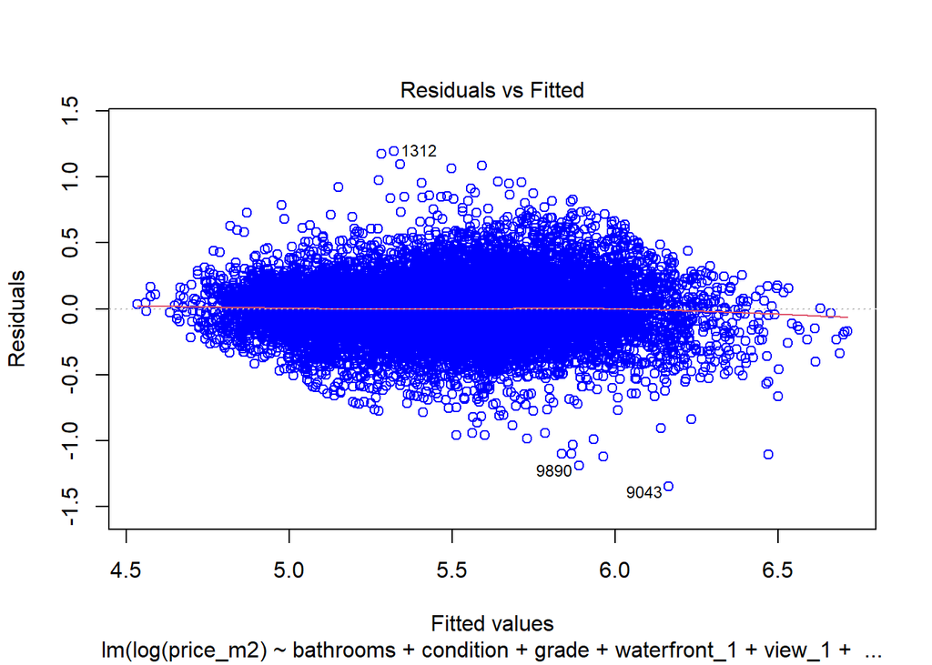

```r
plot(model_AIC, which=1, col=c("blue"))
```

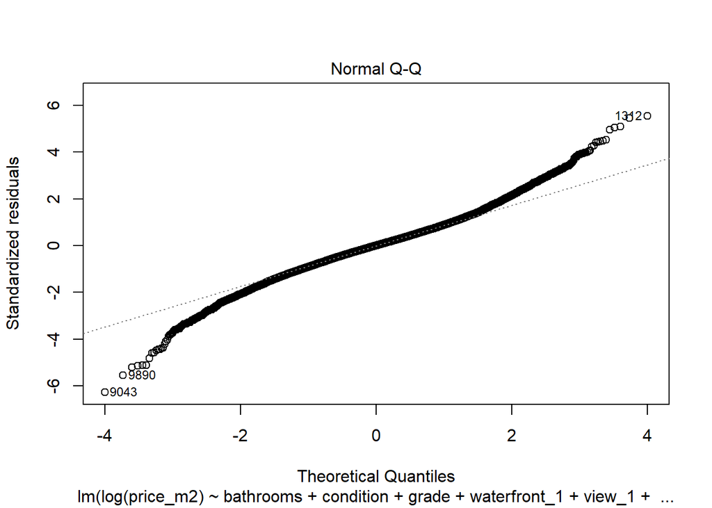

```r
plot(model_AIC, 2)
```

```r
require(nortest)  # Se debe haber instalado nortest
lillie.test(model_AIC$residuals)
```

```
##
##  Lilliefors (Kolmogorov-Smirnov) normality test
##
## data:  model_AIC$residuals
## D = 0.033514, p-value < 2.2e-16
```